# Project: Wrangling and Analyze Data

## Data Gathering:

### 1. The WeRateDogs Twitter Archive

```python
# first importing all relevant libraries
import pandas as pd
import requests
import io
import numpy as np
from pprint import pprint
import matplotlib.pyplot as plt
import matplotlib.image as mpimg
%matplotlib inline
```

```python
# Will gather and read the WeRateDogs twitter archive
enhanced_df= pd.read_csv('twitter-archive-enhanced.csv')
enhanced_df.head()
```

|  | tweet_id | in_reply_to_status_id | in_reply_to_user_id | timestamp | source | text | retweeted_status_id | retweeted_status_user_id | retweeted_status_timestamp | expanded_urls | rating_numerator | rating_denominator | name | doggo | floofer | pupper | puppo |
| --- | --- | --- | --- | --- | --- | --- | --- | --- | --- | --- | --- | --- | --- | --- | --- | --- | --- |
| 0 | 892420643555336193 | NaN | NaN | 2017-08-01 16:23:56 +0000 | <a href="http://twitter.com/download/iphone" r... | This is Phineas. He's a mystical boy. Only eve... | NaN | NaN | NaN | https://twitter.com/dog_rates/status/892420643... | 13 | 10 | Phineas | None | None | None | None |
| 1 | 892177421306343426 | NaN | NaN | 2017-08-01 00:17:27 +0000 | <a href="http://twitter.com/download/iphone" r... | This is Tilly. She's just checking pup on you.... | NaN | NaN | NaN | https://twitter.com/dog_rates/status/892177421... | 13 | 10 | Tilly | None | None | None | None |
| 2 | 891815181378084864 | NaN | NaN | 2017-07-31 00:18:03 +0000 | <a href="http://twitter.com/download/iphone" r... | This is Archie. He is a rare Norwegian Pouncin... | NaN | NaN | NaN | https://twitter.com/dog_rates/status/891815181... | 12 | 10 | Archie | None | None | None | None |
| 3 | 891689557279858688 | NaN | NaN | 2017-07-30 15:58:51 +0000 | <a href="http://twitter.com/download/iphone" r... | This is Darla. She commenced a snooze mid meal... | NaN | NaN | NaN | https://twitter.com/dog_rates/status/891689557... | 13 | 10 | Darla | None | None | None | None |
| 4 | 891327558926688256 | NaN | NaN | 2017-07-29 16:00:24 +0000 | <a href="http://twitter.com/download/iphone" r... | This is Franklin. He would like you to stop ca... | NaN | NaN | NaN | https://twitter.com/dog_rates/status/891327558... | 12 | 10 | Franklin | None | None | None | None |

### 2. The Tweet Image Predictions

```python
import pandas as pd
import requests
import os
```

```python
# making directories if it doesnt already exist
folder_name= 'tweet_image'
if not os.path.exists(folder_name):
    os.makedirs(folder_name)
```

```python
tweet_image_url= 'https://d17h27t6h515a5.cloudfront.net/topher/2017/August/599fd2ad_image-predictions/image-predictions.tsv'
response= requests.get(tweet_image_url)
response
```

```
<Response [200]>
```

```python
tweet_image_url.split('/')[-1]
```

```
'image-predictions.tsv'
```

```python
with open(os.path.join(folder_name, tweet_image_url.split('/')[-1]), mode='wb') as file:
    file.write(response.content)
```

```python
# The image-predictions.tsv file was moved to the home page of the workspace where it can be easily assessed
# Now, reading the file, we have
predictions_df=pd.read_csv('image-predictions.tsv', sep='\t')
predictions_df.head()
```

|  | tweet_id | jpg_url | img_num | p1 | p1_conf | p1_dog | p2 | p2_conf | p2_dog | p3 | p3_conf | p3_dog |
| --- | --- | --- | --- | --- | --- | --- | --- | --- | --- | --- | --- | --- |
| 0 | 666020888022790149 | https://pbs.twimg.com/media/CT4udn0WwAA0aMy.jpg | 1 | Welsh_springer_spaniel | 0.465074 | True | collie | 0.156665 | True | Shetland_sheepdog | 0.061428 | True |
| 1 | 666029285002620928 | https://pbs.twimg.com/media/CT42GRgUYAA5iDo.jpg | 1 | redbone | 0.506826 | True | miniature_pinscher | 0.074192 | True | Rhodesian_ridgeback | 0.072010 | True |
| 2 | 666033412701032449 | https://pbs.twimg.com/media/CT4521TWwAEvMyu.jpg | 1 | German_shepherd | 0.596461 | True | malinois | 0.138584 | True | bloodhound | 0.116197 | True |
| 3 | 666044226329800704 | https://pbs.twimg.com/media/CT5Dr8HUEAA-lEu.jpg | 1 | Rhodesian_ridgeback | 0.408143 | True | redbone | 0.360687 | True | miniature_pinscher | 0.222752 | True |
| 4 | 666049248165822465 | https://pbs.twimg.com/media/CT5IQmsXIAAKY4A.jpg | 1 | miniature_pinscher | 0.560311 | True | Rottweiler | 0.243682 | True | Doberman | 0.154629 | True |

### 3. Data from the Twitter API

```python
import Twitter_access as ta
import tweepy
from tweepy import OAuthHandler
import json
from timeit import default_timer as timer
```

```python
# Quering twitter API for each tweet in the twitter achive and saving JSON in a text file
consumer_key= ta.API_Key
consumer_secret= ta.API_Key_secret
access_token= ta.Access_Token
access_secret= ta.Access_Token_Secret

auth= tweepy.OAuthHandler(consumer_key, consumer_secret)
auth.set_access_token(access_token, access_secret)

api= tweepy.API(auth, wait_on_rate_limit=True)

# Creating tweet IDs for which to gather additional data via Twitter's API
tweet_ids = enhanced_df.tweet_id.values
len(tweet_ids)

# Querying Twitter's API for JSON data for each tweet ID in the Twitter archive
count = 0
fails_dict = {}
start = timer()

# Saving each tweet's returned JSON as a new line in a .txt file
with open('tweet_json.txt', 'w') as outfile:
    for tweet_id in tweet_ids:
        count += 1
        print(str(count) + ": " + str(tweet_id))
        try:
            tweet = api.get_status(tweet_id, tweet_mode='extended')
            print("Success")
            json.dump(tweet._json, outfile)
            outfile.write('\n')
        except tweepy.TweepError as e:
            print("Fail")
            fails_dict[tweet_id] = e
            pass
end = timer()
print(end - start)
print(fails_dict)
```

[output not shown]

[output cut: 4659 more lines]

[output not shown]

#### The dataset has been downloaded and then be written into the tweet_json.txt file.

```python
# Writing the JSON data to a tweet_json.txt file
tweets= []
for line in open('tweet_json.txt', 'r'):
    tweets.append(json.loads(line))
# Printing out the first jason object for reference
tweets[0]
```

[output not shown]

[output cut: 46 more lines]

[output not shown]

```python
# Now creating a list of data from tweet_jason.txt
tweet_json_list= []
for json_data in tweets:
      tweet_json_list.append({'id': json_data['id'],
                              'retweet_count': int(json_data['retweet_count']),
                              'favorite_count': int(json_data['favorite_count'])})
tweet_api_df= pd.DataFrame(tweet_json_list, columns=['id', 'retweet_count', 'favorite_count'])
tweet_api_df.head()
```

|  | id | retweet_count | favorite_count |
| --- | --- | --- | --- |
| 0 | 892420643555336193 | 6982 | 33744 |
| 1 | 892177421306343426 | 5284 | 29274 |
| 2 | 891815181378084864 | 3469 | 22003 |
| 3 | 891689557279858688 | 7205 | 36856 |
| 4 | 891327558926688256 | 7730 | 35235 |

## Assessing Data

```python
enhanced_df
```

|  | tweet_id | in_reply_to_status_id | in_reply_to_user_id | timestamp | source | text | retweeted_status_id | retweeted_status_user_id | retweeted_status_timestamp | expanded_urls | rating_numerator | rating_denominator | name | doggo | floofer | pupper | puppo |
| --- | --- | --- | --- | --- | --- | --- | --- | --- | --- | --- | --- | --- | --- | --- | --- | --- | --- |
| 0 | 892420643555336193 | NaN | NaN | 2017-08-01 16:23:56 +0000 | <a href="http://twitter.com/download/iphone" r... | This is Phineas. He's a mystical boy. Only eve... | NaN | NaN | NaN | https://twitter.com/dog_rates/status/892420643... | 13 | 10 | Phineas | None | None | None | None |
| 1 | 892177421306343426 | NaN | NaN | 2017-08-01 00:17:27 +0000 | <a href="http://twitter.com/download/iphone" r... | This is Tilly. She's just checking pup on you.... | NaN | NaN | NaN | https://twitter.com/dog_rates/status/892177421... | 13 | 10 | Tilly | None | None | None | None |
| 2 | 891815181378084864 | NaN | NaN | 2017-07-31 00:18:03 +0000 | <a href="http://twitter.com/download/iphone" r... | This is Archie. He is a rare Norwegian Pouncin... | NaN | NaN | NaN | https://twitter.com/dog_rates/status/891815181... | 12 | 10 | Archie | None | None | None | None |
| 3 | 891689557279858688 | NaN | NaN | 2017-07-30 15:58:51 +0000 | <a href="http://twitter.com/download/iphone" r... | This is Darla. She commenced a snooze mid meal... | NaN | NaN | NaN | https://twitter.com/dog_rates/status/891689557... | 13 | 10 | Darla | None | None | None | None |
| 4 | 891327558926688256 | NaN | NaN | 2017-07-29 16:00:24 +0000 | <a href="http://twitter.com/download/iphone" r... | This is Franklin. He would like you to stop ca... | NaN | NaN | NaN | https://twitter.com/dog_rates/status/891327558... | 12 | 10 | Franklin | None | None | None | None |
| 5 | 891087950875897856 | NaN | NaN | 2017-07-29 00:08:17 +0000 | <a href="http://twitter.com/download/iphone" r... | Here we have a majestic great white breaching ... | NaN | NaN | NaN | https://twitter.com/dog_rates/status/891087950... | 13 | 10 | None | None | None | None | None |
| 6 | 890971913173991426 | NaN | NaN | 2017-07-28 16:27:12 +0000 | <a href="http://twitter.com/download/iphone" r... | Meet Jax. He enjoys ice cream so much he gets ... | NaN | NaN | NaN | https://gofundme.com/ydvmve-surgery-for-jax,ht... | 13 | 10 | Jax | None | None | None | None |
| 7 | 890729181411237888 | NaN | NaN | 2017-07-28 00:22:40 +0000 | <a href="http://twitter.com/download/iphone" r... | When you watch your owner call another dog a g... | NaN | NaN | NaN | https://twitter.com/dog_rates/status/890729181... | 13 | 10 | None | None | None | None | None |
| 8 | 890609185150312448 | NaN | NaN | 2017-07-27 16:25:51 +0000 | <a href="http://twitter.com/download/iphone" r... | This is Zoey. She doesn't want to be one of th... | NaN | NaN | NaN | https://twitter.com/dog_rates/status/890609185... | 13 | 10 | Zoey | None | None | None | None |
| 9 | 890240255349198849 | NaN | NaN | 2017-07-26 15:59:51 +0000 | <a href="http://twitter.com/download/iphone" r... | This is Cassie. She is a college pup. Studying... | NaN | NaN | NaN | https://twitter.com/dog_rates/status/890240255... | 14 | 10 | Cassie | doggo | None | None | None |
| 10 | 890006608113172480 | NaN | NaN | 2017-07-26 00:31:25 +0000 | <a href="http://twitter.com/download/iphone" r... | This is Koda. He is a South Australian decksha... | NaN | NaN | NaN | https://twitter.com/dog_rates/status/890006608... | 13 | 10 | Koda | None | None | None | None |
| 11 | 889880896479866881 | NaN | NaN | 2017-07-25 16:11:53 +0000 | <a href="http://twitter.com/download/iphone" r... | This is Bruno. He is a service shark. Only get... | NaN | NaN | NaN | https://twitter.com/dog_rates/status/889880896... | 13 | 10 | Bruno | None | None | None | None |
| 12 | 889665388333682689 | NaN | NaN | 2017-07-25 01:55:32 +0000 | <a href="http://twitter.com/download/iphone" r... | Here's a puppo that seems to be on the fence a... | NaN | NaN | NaN | https://twitter.com/dog_rates/status/889665388... | 13 | 10 | None | None | None | None | puppo |
| 13 | 889638837579907072 | NaN | NaN | 2017-07-25 00:10:02 +0000 | <a href="http://twitter.com/download/iphone" r... | This is Ted. He does his best. Sometimes that'... | NaN | NaN | NaN | https://twitter.com/dog_rates/status/889638837... | 12 | 10 | Ted | None | None | None | None |
| 14 | 889531135344209921 | NaN | NaN | 2017-07-24 17:02:04 +0000 | <a href="http://twitter.com/download/iphone" r... | This is Stuart. He's sporting his favorite fan... | NaN | NaN | NaN | https://twitter.com/dog_rates/status/889531135... | 13 | 10 | Stuart | None | None | None | puppo |
| 15 | 889278841981685760 | NaN | NaN | 2017-07-24 00:19:32 +0000 | <a href="http://twitter.com/download/iphone" r... | This is Oliver. You're witnessing one of his m... | NaN | NaN | NaN | https://twitter.com/dog_rates/status/889278841... | 13 | 10 | Oliver | None | None | None | None |
| 16 | 888917238123831296 | NaN | NaN | 2017-07-23 00:22:39 +0000 | <a href="http://twitter.com/download/iphone" r... | This is Jim. He found a fren. Taught him how t... | NaN | NaN | NaN | https://twitter.com/dog_rates/status/888917238... | 12 | 10 | Jim | None | None | None | None |
| 17 | 888804989199671297 | NaN | NaN | 2017-07-22 16:56:37 +0000 | <a href="http://twitter.com/download/iphone" r... | This is Zeke. He has a new stick. Very proud o... | NaN | NaN | NaN | https://twitter.com/dog_rates/status/888804989... | 13 | 10 | Zeke | None | None | None | None |
| 18 | 888554962724278272 | NaN | NaN | 2017-07-22 00:23:06 +0000 | <a href="http://twitter.com/download/iphone" r... | This is Ralphus. He's powering up. Attempting ... | NaN | NaN | NaN | https://twitter.com/dog_rates/status/888554962... | 13 | 10 | Ralphus | None | None | None | None |
| 19 | 888202515573088257 | NaN | NaN | 2017-07-21 01:02:36 +0000 | <a href="http://twitter.com/download/iphone" r... | RT @dog_rates: This is Canela. She attempted s... | 8.874740e+17 | 4.196984e+09 | 2017-07-19 00:47:34 +0000 | https://twitter.com/dog_rates/status/887473957... | 13 | 10 | Canela | None | None | None | None |
| 20 | 888078434458587136 | NaN | NaN | 2017-07-20 16:49:33 +0000 | <a href="http://twitter.com/download/iphone" r... | This is Gerald. He was just told he didn't get... | NaN | NaN | NaN | https://twitter.com/dog_rates/status/888078434... | 12 | 10 | Gerald | None | None | None | None |
| 21 | 887705289381826560 | NaN | NaN | 2017-07-19 16:06:48 +0000 | <a href="http://twitter.com/download/iphone" r... | This is Jeffrey. He has a monopoly on the pool... | NaN | NaN | NaN | https://twitter.com/dog_rates/status/887705289... | 13 | 10 | Jeffrey | None | None | None | None |
| 22 | 887517139158093824 | NaN | NaN | 2017-07-19 03:39:09 +0000 | <a href="http://twitter.com/download/iphone" r... | I've yet to rate a Venezuelan Hover Wiener. Th... | NaN | NaN | NaN | https://twitter.com/dog_rates/status/887517139... | 14 | 10 | such | None | None | None | None |
| 23 | 887473957103951883 | NaN | NaN | 2017-07-19 00:47:34 +0000 | <a href="http://twitter.com/download/iphone" r... | This is Canela. She attempted some fancy porch... | NaN | NaN | NaN | https://twitter.com/dog_rates/status/887473957... | 13 | 10 | Canela | None | None | None | None |
| 24 | 887343217045368832 | NaN | NaN | 2017-07-18 16:08:03 +0000 | <a href="http://twitter.com/download/iphone" r... | You may not have known you needed to see this ... | NaN | NaN | NaN | https://twitter.com/dog_rates/status/887343217... | 13 | 10 | None | None | None | None | None |
| 25 | 887101392804085760 | NaN | NaN | 2017-07-18 00:07:08 +0000 | <a href="http://twitter.com/download/iphone" r... | This... is a Jubilant Antarctic House Bear. We... | NaN | NaN | NaN | https://twitter.com/dog_rates/status/887101392... | 12 | 10 | None | None | None | None | None |
| 26 | 886983233522544640 | NaN | NaN | 2017-07-17 16:17:36 +0000 | <a href="http://twitter.com/download/iphone" r... | This is Maya. She's very shy. Rarely leaves he... | NaN | NaN | NaN | https://twitter.com/dog_rates/status/886983233... | 13 | 10 | Maya | None | None | None | None |
| 27 | 886736880519319552 | NaN | NaN | 2017-07-16 23:58:41 +0000 | <a href="http://twitter.com/download/iphone" r... | This is Mingus. He's a wonderful father to his... | NaN | NaN | NaN | https://www.gofundme.com/mingusneedsus,https:/... | 13 | 10 | Mingus | None | None | None | None |
| 28 | 886680336477933568 | NaN | NaN | 2017-07-16 20:14:00 +0000 | <a href="http://twitter.com/download/iphone" r... | This is Derek. He's late for a dog meeting. 13... | NaN | NaN | NaN | https://twitter.com/dog_rates/status/886680336... | 13 | 10 | Derek | None | None | None | None |
| 29 | 886366144734445568 | NaN | NaN | 2017-07-15 23:25:31 +0000 | <a href="http://twitter.com/download/iphone" r... | This is Roscoe. Another pupper fallen victim t... | NaN | NaN | NaN | https://twitter.com/dog_rates/status/886366144... | 12 | 10 | Roscoe | None | None | pupper | None |
| ... | ... | ... | ... | ... | ... | ... | ... | ... | ... | ... | ... | ... | ... | ... | ... | ... | ... |
| 2326 | 666411507551481857 | NaN | NaN | 2015-11-17 00:24:19 +0000 | <a href="http://twitter.com/download/iphone" r... | This is quite the dog. Gets really excited whe... | NaN | NaN | NaN | https://twitter.com/dog_rates/status/666411507... | 2 | 10 | quite | None | None | None | None |
| 2327 | 666407126856765440 | NaN | NaN | 2015-11-17 00:06:54 +0000 | <a href="http://twitter.com/download/iphone" r... | This is a southern Vesuvius bumblegruff. Can d... | NaN | NaN | NaN | https://twitter.com/dog_rates/status/666407126... | 7 | 10 | a | None | None | None | None |
| 2328 | 666396247373291520 | NaN | NaN | 2015-11-16 23:23:41 +0000 | <a href="http://twitter.com/download/iphone" r... | Oh goodness. A super rare northeast Qdoba kang... | NaN | NaN | NaN | https://twitter.com/dog_rates/status/666396247... | 9 | 10 | None | None | None | None | None |
| 2329 | 666373753744588802 | NaN | NaN | 2015-11-16 21:54:18 +0000 | <a href="http://twitter.com/download/iphone" r... | Those are sunglasses and a jean jacket. 11/10 ... | NaN | NaN | NaN | https://twitter.com/dog_rates/status/666373753... | 11 | 10 | None | None | None | None | None |
| 2330 | 666362758909284353 | NaN | NaN | 2015-11-16 21:10:36 +0000 | <a href="http://twitter.com/download/iphone" r... | Unique dog here. Very small. Lives in containe... | NaN | NaN | NaN | https://twitter.com/dog_rates/status/666362758... | 6 | 10 | None | None | None | None | None |
| 2331 | 666353288456101888 | NaN | NaN | 2015-11-16 20:32:58 +0000 | <a href="http://twitter.com/download/iphone" r... | Here we have a mixed Asiago from the Galápagos... | NaN | NaN | NaN | https://twitter.com/dog_rates/status/666353288... | 8 | 10 | None | None | None | None | None |
| 2332 | 666345417576210432 | NaN | NaN | 2015-11-16 20:01:42 +0000 | <a href="http://twitter.com/download/iphone" r... | Look at this jokester thinking seat belt laws ... | NaN | NaN | NaN | https://twitter.com/dog_rates/status/666345417... | 10 | 10 | None | None | None | None | None |
| 2333 | 666337882303524864 | NaN | NaN | 2015-11-16 19:31:45 +0000 | <a href="http://twitter.com/download/iphone" r... | This is an extremely rare horned Parthenon. No... | NaN | NaN | NaN | https://twitter.com/dog_rates/status/666337882... | 9 | 10 | an | None | None | None | None |
| 2334 | 666293911632134144 | NaN | NaN | 2015-11-16 16:37:02 +0000 | <a href="http://twitter.com/download/iphone" r... | This is a funny dog. Weird toes. Won't come do... | NaN | NaN | NaN | https://twitter.com/dog_rates/status/666293911... | 3 | 10 | a | None | None | None | None |
| 2335 | 666287406224695296 | NaN | NaN | 2015-11-16 16:11:11 +0000 | <a href="http://twitter.com/download/iphone" r... | This is an Albanian 3 1/2 legged Episcopalian... | NaN | NaN | NaN | https://twitter.com/dog_rates/status/666287406... | 1 | 2 | an | None | None | None | None |
| 2336 | 666273097616637952 | NaN | NaN | 2015-11-16 15:14:19 +0000 | <a href="http://twitter.com/download/iphone" r... | Can take selfies 11/10 https://t.co/ws2AMaNwPW | NaN | NaN | NaN | https://twitter.com/dog_rates/status/666273097... | 11 | 10 | None | None | None | None | None |
| 2337 | 666268910803644416 | NaN | NaN | 2015-11-16 14:57:41 +0000 | <a href="http://twitter.com/download/iphone" r... | Very concerned about fellow dog trapped in com... | NaN | NaN | NaN | https://twitter.com/dog_rates/status/666268910... | 10 | 10 | None | None | None | None | None |
| 2338 | 666104133288665088 | NaN | NaN | 2015-11-16 04:02:55 +0000 | <a href="http://twitter.com/download/iphone" r... | Not familiar with this breed. No tail (weird).... | NaN | NaN | NaN | https://twitter.com/dog_rates/status/666104133... | 1 | 10 | None | None | None | None | None |
| 2339 | 666102155909144576 | NaN | NaN | 2015-11-16 03:55:04 +0000 | <a href="http://twitter.com/download/iphone" r... | Oh my. Here you are seeing an Adobe Setter giv... | NaN | NaN | NaN | https://twitter.com/dog_rates/status/666102155... | 11 | 10 | None | None | None | None | None |
| 2340 | 666099513787052032 | NaN | NaN | 2015-11-16 03:44:34 +0000 | <a href="http://twitter.com/download/iphone" r... | Can stand on stump for what seems like a while... | NaN | NaN | NaN | https://twitter.com/dog_rates/status/666099513... | 8 | 10 | None | None | None | None | None |
| 2341 | 666094000022159362 | NaN | NaN | 2015-11-16 03:22:39 +0000 | <a href="http://twitter.com/download/iphone" r... | This appears to be a Mongolian Presbyterian mi... | NaN | NaN | NaN | https://twitter.com/dog_rates/status/666094000... | 9 | 10 | None | None | None | None | None |
| 2342 | 666082916733198337 | NaN | NaN | 2015-11-16 02:38:37 +0000 | <a href="http://twitter.com/download/iphone" r... | Here we have a well-established sunblockerspan... | NaN | NaN | NaN | https://twitter.com/dog_rates/status/666082916... | 6 | 10 | None | None | None | None | None |
| 2343 | 666073100786774016 | NaN | NaN | 2015-11-16 01:59:36 +0000 | <a href="http://twitter.com/download/iphone" r... | Let's hope this flight isn't Malaysian (lol). ... | NaN | NaN | NaN | https://twitter.com/dog_rates/status/666073100... | 10 | 10 | None | None | None | None | None |
| 2344 | 666071193221509120 | NaN | NaN | 2015-11-16 01:52:02 +0000 | <a href="http://twitter.com/download/iphone" r... | Here we have a northern speckled Rhododendron.... | NaN | NaN | NaN | https://twitter.com/dog_rates/status/666071193... | 9 | 10 | None | None | None | None | None |
| 2345 | 666063827256086533 | NaN | NaN | 2015-11-16 01:22:45 +0000 | <a href="http://twitter.com/download/iphone" r... | This is the happiest dog you will ever see. Ve... | NaN | NaN | NaN | https://twitter.com/dog_rates/status/666063827... | 10 | 10 | the | None | None | None | None |
| 2346 | 666058600524156928 | NaN | NaN | 2015-11-16 01:01:59 +0000 | <a href="http://twitter.com/download/iphone" r... | Here is the Rand Paul of retrievers folks! He'... | NaN | NaN | NaN | https://twitter.com/dog_rates/status/666058600... | 8 | 10 | the | None | None | None | None |
| 2347 | 666057090499244032 | NaN | NaN | 2015-11-16 00:55:59 +0000 | <a href="http://twitter.com/download/iphone" r... | My oh my. This is a rare blond Canadian terrie... | NaN | NaN | NaN | https://twitter.com/dog_rates/status/666057090... | 9 | 10 | a | None | None | None | None |
| 2348 | 666055525042405380 | NaN | NaN | 2015-11-16 00:49:46 +0000 | <a href="http://twitter.com/download/iphone" r... | Here is a Siberian heavily armored polar bear ... | NaN | NaN | NaN | https://twitter.com/dog_rates/status/666055525... | 10 | 10 | a | None | None | None | None |
| 2349 | 666051853826850816 | NaN | NaN | 2015-11-16 00:35:11 +0000 | <a href="http://twitter.com/download/iphone" r... | This is an odd dog. Hard on the outside but lo... | NaN | NaN | NaN | https://twitter.com/dog_rates/status/666051853... | 2 | 10 | an | None | None | None | None |
| 2350 | 666050758794694657 | NaN | NaN | 2015-11-16 00:30:50 +0000 | <a href="http://twitter.com/download/iphone" r... | This is a truly beautiful English Wilson Staff... | NaN | NaN | NaN | https://twitter.com/dog_rates/status/666050758... | 10 | 10 | a | None | None | None | None |
| 2351 | 666049248165822465 | NaN | NaN | 2015-11-16 00:24:50 +0000 | <a href="http://twitter.com/download/iphone" r... | Here we have a 1949 1st generation vulpix. Enj... | NaN | NaN | NaN | https://twitter.com/dog_rates/status/666049248... | 5 | 10 | None | None | None | None | None |
| 2352 | 666044226329800704 | NaN | NaN | 2015-11-16 00:04:52 +0000 | <a href="http://twitter.com/download/iphone" r... | This is a purebred Piers Morgan. Loves to Netf... | NaN | NaN | NaN | https://twitter.com/dog_rates/status/666044226... | 6 | 10 | a | None | None | None | None |
| 2353 | 666033412701032449 | NaN | NaN | 2015-11-15 23:21:54 +0000 | <a href="http://twitter.com/download/iphone" r... | Here is a very happy pup. Big fan of well-main... | NaN | NaN | NaN | https://twitter.com/dog_rates/status/666033412... | 9 | 10 | a | None | None | None | None |
| 2354 | 666029285002620928 | NaN | NaN | 2015-11-15 23:05:30 +0000 | <a href="http://twitter.com/download/iphone" r... | This is a western brown Mitsubishi terrier. Up... | NaN | NaN | NaN | https://twitter.com/dog_rates/status/666029285... | 7 | 10 | a | None | None | None | None |
| 2355 | 666020888022790149 | NaN | NaN | 2015-11-15 22:32:08 +0000 | <a href="http://twitter.com/download/iphone" r... | Here we have a Japanese Irish Setter. Lost eye... | NaN | NaN | NaN | https://twitter.com/dog_rates/status/666020888... | 8 | 10 | None | None | None | None | None |

2356 rows × 17 columns

```python
enhanced_df.info()
```

```
<class 'pandas.core.frame.DataFrame'>
RangeIndex: 2356 entries, 0 to 2355
Data columns (total 17 columns):
tweet_id                      2356 non-null int64
in_reply_to_status_id         78 non-null float64
in_reply_to_user_id           78 non-null float64
timestamp                     2356 non-null object
source                        2356 non-null object
text                          2356 non-null object
retweeted_status_id           181 non-null float64
retweeted_status_user_id      181 non-null float64
retweeted_status_timestamp    181 non-null object
expanded_urls                 2297 non-null object
rating_numerator              2356 non-null int64
rating_denominator            2356 non-null int64
name                          2356 non-null object
doggo                         2356 non-null object
floofer                       2356 non-null object
pupper                        2356 non-null object
puppo                         2356 non-null object
dtypes: float64(4), int64(3), object(10)
memory usage: 313.0+ KB
```

#### * There are so many missing values in some columns, many of which are not needed in the analysis

#### * The timestamp has object datatype instead of datetime. More so, the "+0000" attached to it is an irrelevant information

#### * The ratings are expected to be floats and not integers

#### * Out of 2356 inputs, there are only 181 retweeted_status_id, which are not needed for analysis since only the original tweets are relevant.

```python
enhanced_df.describe()
```

|  | tweet_id | in_reply_to_status_id | in_reply_to_user_id | retweeted_status_id | retweeted_status_user_id | rating_numerator | rating_denominator |
| --- | --- | --- | --- | --- | --- | --- | --- |
| count | 2.356000e+03 | 7.800000e+01 | 7.800000e+01 | 1.810000e+02 | 1.810000e+02 | 2356.000000 | 2356.000000 |
| mean | 7.427716e+17 | 7.455079e+17 | 2.014171e+16 | 7.720400e+17 | 1.241698e+16 | 13.126486 | 10.455433 |
| std | 6.856705e+16 | 7.582492e+16 | 1.252797e+17 | 6.236928e+16 | 9.599254e+16 | 45.876648 | 6.745237 |
| min | 6.660209e+17 | 6.658147e+17 | 1.185634e+07 | 6.661041e+17 | 7.832140e+05 | 0.000000 | 0.000000 |
| 25% | 6.783989e+17 | 6.757419e+17 | 3.086374e+08 | 7.186315e+17 | 4.196984e+09 | 10.000000 | 10.000000 |
| 50% | 7.196279e+17 | 7.038708e+17 | 4.196984e+09 | 7.804657e+17 | 4.196984e+09 | 11.000000 | 10.000000 |
| 75% | 7.993373e+17 | 8.257804e+17 | 4.196984e+09 | 8.203146e+17 | 4.196984e+09 | 12.000000 | 10.000000 |
| max | 8.924206e+17 | 8.862664e+17 | 8.405479e+17 | 8.874740e+17 | 7.874618e+17 | 1776.000000 | 170.000000 |

#### There are some inaccurate data sighted in the rating_numerator/rating_denominator columns.

```python
enhanced_df['rating_denominator'].value_counts()
```

```
10     2333
11        3
50        3
80        2
20        2
2         1
16        1
40        1
70        1
15        1
90        1
110       1
120       1
130       1
150       1
170       1
7         1
0         1
Name: rating_denominator, dtype: int64
```

#### Since the ratings almost always have a denominator of 10, it is assumed that the denominator will have a value of only 10.

```python
enhanced_df['rating_numerator'].value_counts().head(20)
```

```
12     558
11     464
10     461
13     351
9      158
8      102
7       55
14      54
5       37
6       32
3       19
4       17
1        9
2        9
420      2
0        2
15       2
75       2
80       1
20       1
Name: rating_numerator, dtype: int64
```

#### The numerator is mostly between 0 and 15. Any value outside this range is considered an outlier.

```python
enhanced_df[enhanced_df.rating_numerator > 15]
```

|  | tweet_id | in_reply_to_status_id | in_reply_to_user_id | timestamp | source | text | retweeted_status_id | retweeted_status_user_id | retweeted_status_timestamp | expanded_urls | rating_numerator | rating_denominator | name | doggo | floofer | pupper | puppo |
| --- | --- | --- | --- | --- | --- | --- | --- | --- | --- | --- | --- | --- | --- | --- | --- | --- | --- |
| 55 | 881633300179243008 | 8.816070e+17 | 4.738443e+07 | 2017-07-02 21:58:53 +0000 | <a href="http://twitter.com/download/iphone" r... | @roushfenway These are good dogs but 17/10 is ... | NaN | NaN | NaN | NaN | 17 | 10 | None | None | None | None | None |
| 188 | 855862651834028034 | 8.558616e+17 | 1.943518e+08 | 2017-04-22 19:15:32 +0000 | <a href="http://twitter.com/download/iphone" r... | @dhmontgomery We also gave snoop dogg a 420/10... | NaN | NaN | NaN | NaN | 420 | 10 | None | None | None | None | None |
| 189 | 855860136149123072 | 8.558585e+17 | 1.361572e+07 | 2017-04-22 19:05:32 +0000 | <a href="http://twitter.com/download/iphone" r... | @s8n You tried very hard to portray this good ... | NaN | NaN | NaN | NaN | 666 | 10 | None | None | None | None | None |
| 290 | 838150277551247360 | 8.381455e+17 | 2.195506e+07 | 2017-03-04 22:12:52 +0000 | <a href="http://twitter.com/download/iphone" r... | @markhoppus 182/10 | NaN | NaN | NaN | NaN | 182 | 10 | None | None | None | None | None |
| 313 | 835246439529840640 | 8.352460e+17 | 2.625958e+07 | 2017-02-24 21:54:03 +0000 | <a href="http://twitter.com/download/iphone" r... | @jonnysun @Lin_Manuel ok jomny I know you're e... | NaN | NaN | NaN | NaN | 960 | 0 | None | None | None | None | None |
| 340 | 832215909146226688 | NaN | NaN | 2017-02-16 13:11:49 +0000 | <a href="http://twitter.com/download/iphone" r... | RT @dog_rates: This is Logan, the Chow who liv... | 7.867091e+17 | 4.196984e+09 | 2016-10-13 23:23:56 +0000 | https://twitter.com/dog_rates/status/786709082... | 75 | 10 | Logan | None | None | None | None |
| 433 | 820690176645140481 | NaN | NaN | 2017-01-15 17:52:40 +0000 | <a href="http://twitter.com/download/iphone" r... | The floofs have been released I repeat the flo... | NaN | NaN | NaN | https://twitter.com/dog_rates/status/820690176... | 84 | 70 | None | None | None | None | None |
| 516 | 810984652412424192 | NaN | NaN | 2016-12-19 23:06:23 +0000 | <a href="http://twitter.com/download/iphone" r... | Meet Sam. She smiles 24/7 &amp; secretly aspir... | NaN | NaN | NaN | https://www.gofundme.com/sams-smile,https://tw... | 24 | 7 | Sam | None | None | None | None |
| 695 | 786709082849828864 | NaN | NaN | 2016-10-13 23:23:56 +0000 | <a href="http://twitter.com/download/iphone" r... | This is Logan, the Chow who lived. He solemnly... | NaN | NaN | NaN | https://twitter.com/dog_rates/status/786709082... | 75 | 10 | Logan | None | None | None | None |
| 763 | 778027034220126208 | NaN | NaN | 2016-09-20 00:24:34 +0000 | <a href="http://twitter.com/download/iphone" r... | This is Sophie. She's a Jubilant Bush Pupper. ... | NaN | NaN | NaN | https://twitter.com/dog_rates/status/778027034... | 27 | 10 | Sophie | None | None | pupper | None |
| 902 | 758467244762497024 | NaN | NaN | 2016-07-28 01:00:57 +0000 | <a href="http://twitter.com/download/iphone" r... | Why does this never happen at my front door...... | NaN | NaN | NaN | https://twitter.com/dog_rates/status/758467244... | 165 | 150 | None | None | None | None | None |
| 979 | 749981277374128128 | NaN | NaN | 2016-07-04 15:00:45 +0000 | <a href="https://about.twitter.com/products/tw... | This is Atticus. He's quite simply America af.... | NaN | NaN | NaN | https://twitter.com/dog_rates/status/749981277... | 1776 | 10 | Atticus | None | None | None | None |
| 1120 | 731156023742988288 | NaN | NaN | 2016-05-13 16:15:54 +0000 | <a href="http://twitter.com/download/iphone" r... | Say hello to this unbelievably well behaved sq... | NaN | NaN | NaN | https://twitter.com/dog_rates/status/731156023... | 204 | 170 | this | None | None | None | None |
| 1202 | 716439118184652801 | NaN | NaN | 2016-04-03 01:36:11 +0000 | <a href="http://twitter.com/download/iphone" r... | This is Bluebert. He just saw that both #Final... | NaN | NaN | NaN | https://twitter.com/dog_rates/status/716439118... | 50 | 50 | Bluebert | None | None | None | None |
| 1228 | 713900603437621249 | NaN | NaN | 2016-03-27 01:29:02 +0000 | <a href="http://twitter.com/download/iphone" r... | Happy Saturday here's 9 puppers on a bench. 99... | NaN | NaN | NaN | https://twitter.com/dog_rates/status/713900603... | 99 | 90 | None | None | None | None | None |
| 1254 | 710658690886586372 | NaN | NaN | 2016-03-18 02:46:49 +0000 | <a href="http://twitter.com/download/iphone" r... | Here's a brigade of puppers. All look very pre... | NaN | NaN | NaN | https://twitter.com/dog_rates/status/710658690... | 80 | 80 | None | None | None | None | None |
| 1274 | 709198395643068416 | NaN | NaN | 2016-03-14 02:04:08 +0000 | <a href="http://twitter.com/download/iphone" r... | From left to right:\nCletus, Jerome, Alejandro... | NaN | NaN | NaN | https://twitter.com/dog_rates/status/709198395... | 45 | 50 | None | None | None | None | None |
| 1351 | 704054845121142784 | NaN | NaN | 2016-02-28 21:25:30 +0000 | <a href="http://twitter.com/download/iphone" r... | Here is a whole flock of puppers. 60/50 I'll ... | NaN | NaN | NaN | https://twitter.com/dog_rates/status/704054845... | 60 | 50 | a | None | None | None | None |
| 1433 | 697463031882764288 | NaN | NaN | 2016-02-10 16:51:59 +0000 | <a href="http://twitter.com/download/iphone" r... | Happy Wednesday here's a bucket of pups. 44/40... | NaN | NaN | NaN | https://twitter.com/dog_rates/status/697463031... | 44 | 40 | None | None | None | None | None |
| 1634 | 684225744407494656 | 6.842229e+17 | 4.196984e+09 | 2016-01-05 04:11:44 +0000 | <a href="http://twitter.com/download/iphone" r... | Two sneaky puppers were not initially seen, mo... | NaN | NaN | NaN | https://twitter.com/dog_rates/status/684225744... | 143 | 130 | None | None | None | None | None |
| 1635 | 684222868335505415 | NaN | NaN | 2016-01-05 04:00:18 +0000 | <a href="http://twitter.com/download/iphone" r... | Someone help the girl is being mugged. Several... | NaN | NaN | NaN | https://twitter.com/dog_rates/status/684222868... | 121 | 110 | None | None | None | None | None |
| 1663 | 682808988178739200 | 6.827884e+17 | 4.196984e+09 | 2016-01-01 06:22:03 +0000 | <a href="http://twitter.com/download/iphone" r... | I'm aware that I could've said 20/16, but here... | NaN | NaN | NaN | NaN | 20 | 16 | None | None | None | None | None |
| 1712 | 680494726643068929 | NaN | NaN | 2015-12-25 21:06:00 +0000 | <a href="http://twitter.com/download/iphone" r... | Here we have uncovered an entire battalion of ... | NaN | NaN | NaN | https://twitter.com/dog_rates/status/680494726... | 26 | 10 | None | None | None | None | None |
| 1779 | 677716515794329600 | NaN | NaN | 2015-12-18 05:06:23 +0000 | <a href="http://twitter.com/download/iphone" r... | IT'S PUPPERGEDDON. Total of 144/120 ...I think... | NaN | NaN | NaN | https://twitter.com/dog_rates/status/677716515... | 144 | 120 | None | None | None | None | None |
| 1843 | 675853064436391936 | NaN | NaN | 2015-12-13 01:41:41 +0000 | <a href="http://twitter.com/download/iphone" r... | Here we have an entire platoon of puppers. Tot... | NaN | NaN | NaN | https://twitter.com/dog_rates/status/675853064... | 88 | 80 | None | None | None | None | None |
| 2074 | 670842764863651840 | NaN | NaN | 2015-11-29 05:52:33 +0000 | <a href="http://twitter.com/download/iphone" r... | After so many requests... here you go.\n\nGood... | NaN | NaN | NaN | https://twitter.com/dog_rates/status/670842764... | 420 | 10 | None | None | None | None | None |

```python
enhanced_df.name.value_counts()
```

```
None        745
a            55
Charlie      12
Cooper       11
Oliver       11
Lucy         11
Lola         10
Tucker       10
Penny        10
Winston       9
Bo            9
the           8
Sadie         8
an            7
Buddy         7
Bailey        7
Toby          7
Daisy         7
Bella         6
Leo           6
Stanley       6
Jax           6
Milo          6
Jack          6
Rusty         6
Koda          6
Scout         6
Oscar         6
Dave          6
George        5
           ...
Meera         1
Mollie        1
Dot           1
Mairi         1
Darby         1
Perry         1
Livvie        1
such          1
Crimson       1
Toffee        1
Terrenth      1
Beebop        1
Harlso        1
Richie        1
Jomathan      1
Cal           1
Vince         1
Heinrich      1
Cecil         1
Ace           1
Pherb         1
Sweets        1
Griswold      1
Liam          1
Grizz         1
old           1
Zeek          1
Ambrose       1
Lizzie        1
Durg          1
Name: name, Length: 957, dtype: int64
```

```python
enhanced_df.name.unique()
```

```
array(['Phineas', 'Tilly', 'Archie', 'Darla', 'Franklin', 'None', 'Jax',
       'Zoey', 'Cassie', 'Koda', 'Bruno', 'Ted', 'Stuart', 'Oliver', 'Jim',
       'Zeke', 'Ralphus', 'Canela', 'Gerald', 'Jeffrey', 'such', 'Maya',
       'Mingus', 'Derek', 'Roscoe', 'Waffles', 'Jimbo', 'Maisey', 'Lilly',
       'Earl', 'Lola', 'Kevin', 'Yogi', 'Noah', 'Bella', 'Grizzwald',
       'Rusty', 'Gus', 'Stanley', 'Alfy', 'Koko', 'Rey', 'Gary', 'a',
       'Elliot', 'Louis', 'Jesse', 'Romeo', 'Bailey', 'Duddles', 'Jack',
       'Emmy', 'Steven', 'Beau', 'Snoopy', 'Shadow', 'Terrance', 'Aja',
       'Penny', 'Dante', 'Nelly', 'Ginger', 'Benedict', 'Venti', 'Goose',
       'Nugget', 'Cash', 'Coco', 'Jed', 'Sebastian', 'Walter', 'Sierra',
       'Monkey', 'Harry', 'Kody', 'Lassie', 'Rover', 'Napolean', 'Dawn',
       'Boomer', 'Cody', 'Rumble', 'Clifford', 'quite', 'Dewey', 'Scout',
       'Gizmo', 'Cooper', 'Harold', 'Shikha', 'Jamesy', 'Lili', 'Sammy',
       'Meatball', 'Paisley', 'Albus', 'Neptune', 'Quinn', 'Belle',
       'Zooey', 'Dave', 'Jersey', 'Hobbes', 'Burt', 'Lorenzo', 'Carl',
       'Jordy', 'Milky', 'Trooper', 'Winston', 'Sophie', 'Wyatt', 'Rosie',
       'Thor', 'Oscar', 'Luna', 'Callie', 'Cermet', 'George', 'Marlee',
       'Arya', 'Einstein', 'Alice', 'Rumpole', 'Benny', 'Aspen', 'Jarod',
       'Wiggles', 'General', 'Sailor', 'Astrid', 'Iggy', 'Snoop', 'Kyle',
       'Leo', 'Riley', 'Gidget', 'Noosh', 'Odin', 'Jerry', 'Charlie',
       'Georgie', 'Rontu', 'Cannon', 'Furzey', 'Daisy', 'Tuck', 'Barney',
       'Vixen', 'Jarvis', 'Mimosa', 'Pickles', 'Bungalo', 'Brady', 'Margo',
       'Sadie', 'Hank', 'Tycho', 'Stephan', 'Indie', 'Winnie', 'Bentley',
       'Ken', 'Max', 'Maddie', 'Pipsy', 'Monty', 'Sojourner', 'Odie',
       'Arlo', 'Sunny', 'Vincent', 'Lucy', 'Clark', 'Mookie', 'Meera',
       'Buddy', 'Ava', 'Rory', 'Eli', 'Ash', 'Tucker', 'Tobi', 'Chester',
       'Wilson', 'Sunshine', 'Lipton', 'Gabby', 'Bronte', 'Poppy', 'Rhino',
       'Willow', 'not', 'Orion', 'Eevee', 'Smiley', 'Logan', 'Moreton',
       'Klein', 'Miguel', 'Emanuel', 'Kuyu', 'Dutch', 'Pete', 'Scooter',
       'Reggie', 'Kyro', 'Samson', 'Loki', 'Mia', 'Malcolm', 'Dexter',
       'Alfie', 'Fiona', 'one', 'Mutt', 'Bear', 'Doobert', 'Beebop',
       'Alexander', 'Sailer', 'Brutus', 'Kona', 'Boots', 'Ralphie', 'Phil',
       'Cupid', 'Pawnd', 'Pilot', 'Ike', 'Mo', 'Toby', 'Sweet', 'Pablo',
       'Nala', 'Balto', 'Crawford', 'Gabe', 'Mattie', 'Jimison',
       'Hercules', 'Duchess', 'Harlso', 'Sampson', 'Sundance', 'Luca',
       'Flash', 'Finn', 'Peaches', 'Howie', 'Jazzy', 'Anna', 'Bo',
       'Seamus', 'Wafer', 'Chelsea', 'Tom', 'Moose', 'Florence', 'Autumn',
       'Dido', 'Eugene', 'Herschel', 'Strudel', 'Tebow', 'Chloe', 'Betty',
       'Timber', 'Binky', 'Dudley', 'Comet', 'Larry', 'Levi', 'Akumi',
       'Titan', 'Olivia', 'Alf', 'Oshie', 'Bruce', 'Chubbs', 'Sky',
```

[output cut: 85 more lines]

```
       'Julius', 'Tanner', 'Sparky', 'Anthony', 'Holly', 'Jett', 'Amy',
       'Sage', 'Andy', 'Mason', 'Trigger', 'Antony', 'Creg', 'Traviss',
       'Gin', 'Jeffrie', 'Danny', 'Ester', 'Pluto', 'Bloo', 'Edd', 'Willy',
       'Herb', 'Damon', 'Peanut', 'Nigel', 'Butters', 'Sandra', 'Fabio',
       'Randall', 'Liam', 'Tommy', 'Ben', 'Raphael', 'Julio', 'Andru',
       'Kloey', 'Shawwn', 'Skye', 'Kollin', 'Ronduh', 'Billl', 'Saydee',
       'Dug', 'Tessa', 'Sully', 'Kirk', 'Ralf', 'Clarq', 'Jaspers',
       'Samsom', 'Harrison', 'Chaz', 'Jeremy', 'Jaycob', 'Lambeau',
       'Ruffles', 'Amélie', 'Bobb', 'Banditt', 'Kevon', 'Winifred', 'Hanz',
       'Churlie', 'Zeek', 'Timofy', 'Maks', 'Jomathan', 'Kallie', 'Marvin',
       'Spark', 'Gòrdón', 'Jo', 'DayZ', 'Jareld', 'Torque', 'Ron',
       'Skittles', 'Cleopatricia', 'Erik', 'Stu', 'Tedrick', 'Filup',
       'Kial', 'Naphaniel', 'Dook', 'Hall', 'Philippe', 'Biden', 'Fwed',
       'Genevieve', 'Joshwa', 'Bradlay', 'Clybe', 'Keet', 'Carll',
       'Jockson', 'Josep', 'Lugan', 'Christoper'], dtype=object)
```

```python
# Checking for dog names in lower case
lower_case = enhanced_df.name.str.contains('^[a-z]', regex = True)
enhanced_df[lower_case].name.value_counts().sort_index()
```

```
a               55
actually         2
all              1
an               7
by               1
getting          2
his              1
incredibly       1
infuriating      1
just             4
life             1
light            1
mad              2
my               1
not              2
officially       1
old              1
one              4
quite            4
space            1
such             1
the              8
this             1
unacceptable     1
very             5
Name: name, dtype: int64
```

```python
enhanced_df.groupby(["doggo", "floofer", "pupper", "puppo"]).size().reset_index().rename(columns={0: "count"})
```

|  | doggo | floofer | pupper | puppo | count |
| --- | --- | --- | --- | --- | --- |
| 0 | None | None | None | None | 1976 |
| 1 | None | None | None | puppo | 29 |
| 2 | None | None | pupper | None | 245 |
| 3 | None | floofer | None | None | 9 |
| 4 | doggo | None | None | None | 83 |
| 5 | doggo | None | None | puppo | 1 |
| 6 | doggo | None | pupper | None | 12 |
| 7 | doggo | floofer | None | None | 1 |

```python
predictions_df.head(20)
```

|  | tweet_id | jpg_url | img_num | p1 | p1_conf | p1_dog | p2 | p2_conf | p2_dog | p3 | p3_conf | p3_dog |
| --- | --- | --- | --- | --- | --- | --- | --- | --- | --- | --- | --- | --- |
| 0 | 666020888022790149 | https://pbs.twimg.com/media/CT4udn0WwAA0aMy.jpg | 1 | Welsh_springer_spaniel | 0.465074 | True | collie | 0.156665 | True | Shetland_sheepdog | 0.061428 | True |
| 1 | 666029285002620928 | https://pbs.twimg.com/media/CT42GRgUYAA5iDo.jpg | 1 | redbone | 0.506826 | True | miniature_pinscher | 0.074192 | True | Rhodesian_ridgeback | 0.072010 | True |
| 2 | 666033412701032449 | https://pbs.twimg.com/media/CT4521TWwAEvMyu.jpg | 1 | German_shepherd | 0.596461 | True | malinois | 0.138584 | True | bloodhound | 0.116197 | True |
| 3 | 666044226329800704 | https://pbs.twimg.com/media/CT5Dr8HUEAA-lEu.jpg | 1 | Rhodesian_ridgeback | 0.408143 | True | redbone | 0.360687 | True | miniature_pinscher | 0.222752 | True |
| 4 | 666049248165822465 | https://pbs.twimg.com/media/CT5IQmsXIAAKY4A.jpg | 1 | miniature_pinscher | 0.560311 | True | Rottweiler | 0.243682 | True | Doberman | 0.154629 | True |
| 5 | 666050758794694657 | https://pbs.twimg.com/media/CT5Jof1WUAEuVxN.jpg | 1 | Bernese_mountain_dog | 0.651137 | True | English_springer | 0.263788 | True | Greater_Swiss_Mountain_dog | 0.016199 | True |
| 6 | 666051853826850816 | https://pbs.twimg.com/media/CT5KoJ1WoAAJash.jpg | 1 | box_turtle | 0.933012 | False | mud_turtle | 0.045885 | False | terrapin | 0.017885 | False |
| 7 | 666055525042405380 | https://pbs.twimg.com/media/CT5N9tpXIAAifs1.jpg | 1 | chow | 0.692517 | True | Tibetan_mastiff | 0.058279 | True | fur_coat | 0.054449 | False |
| 8 | 666057090499244032 | https://pbs.twimg.com/media/CT5PY90WoAAQGLo.jpg | 1 | shopping_cart | 0.962465 | False | shopping_basket | 0.014594 | False | golden_retriever | 0.007959 | True |
| 9 | 666058600524156928 | https://pbs.twimg.com/media/CT5Qw94XAAA_2dP.jpg | 1 | miniature_poodle | 0.201493 | True | komondor | 0.192305 | True | soft-coated_wheaten_terrier | 0.082086 | True |
| 10 | 666063827256086533 | https://pbs.twimg.com/media/CT5Vg_wXIAAXfnj.jpg | 1 | golden_retriever | 0.775930 | True | Tibetan_mastiff | 0.093718 | True | Labrador_retriever | 0.072427 | True |
| 11 | 666071193221509120 | https://pbs.twimg.com/media/CT5cN_3WEAAlOoZ.jpg | 1 | Gordon_setter | 0.503672 | True | Yorkshire_terrier | 0.174201 | True | Pekinese | 0.109454 | True |
| 12 | 666073100786774016 | https://pbs.twimg.com/media/CT5d9DZXAAALcwe.jpg | 1 | Walker_hound | 0.260857 | True | English_foxhound | 0.175382 | True | Ibizan_hound | 0.097471 | True |
| 13 | 666082916733198337 | https://pbs.twimg.com/media/CT5m4VGWEAAtKc8.jpg | 1 | pug | 0.489814 | True | bull_mastiff | 0.404722 | True | French_bulldog | 0.048960 | True |
| 14 | 666094000022159362 | https://pbs.twimg.com/media/CT5w9gUW4AAsBNN.jpg | 1 | bloodhound | 0.195217 | True | German_shepherd | 0.078260 | True | malinois | 0.075628 | True |
| 15 | 666099513787052032 | https://pbs.twimg.com/media/CT51-JJUEAA6hV8.jpg | 1 | Lhasa | 0.582330 | True | Shih-Tzu | 0.166192 | True | Dandie_Dinmont | 0.089688 | True |
| 16 | 666102155909144576 | https://pbs.twimg.com/media/CT54YGiWUAEZnoK.jpg | 1 | English_setter | 0.298617 | True | Newfoundland | 0.149842 | True | borzoi | 0.133649 | True |
| 17 | 666104133288665088 | https://pbs.twimg.com/media/CT56LSZWoAAlJj2.jpg | 1 | hen | 0.965932 | False | cock | 0.033919 | False | partridge | 0.000052 | False |
| 18 | 666268910803644416 | https://pbs.twimg.com/media/CT8QCd1WEAADXws.jpg | 1 | desktop_computer | 0.086502 | False | desk | 0.085547 | False | bookcase | 0.079480 | False |
| 19 | 666273097616637952 | https://pbs.twimg.com/media/CT8T1mtUwAA3aqm.jpg | 1 | Italian_greyhound | 0.176053 | True | toy_terrier | 0.111884 | True | basenji | 0.111152 | True |

#### The image predictions p1, p2 and p3 are inconsistent because some have their first letter writen in capital and small letters.

### Quality issues

#### predictions_df Dataframe

1. The image predictions p1, p2 and p3 are inconsistent because some have their first letter written in capital and small letters.

### Tidiness issues

1. The variables (doggo, floofer, pupper and puppo) in enhanced_df table should all be in one column. Notice there are cases where multiple dog stages in a row are found.
2. enhanced_df, predictions_df and tweet_api_df should form one observational unit

## Quality Issues

### Issue #1:

#### Drop the following variables ( 'in_reply_to_status_id', 'in_reply_to_user_id', 'retweeted_status_user_id' and 'retweeted_status_timestamp') in enhanced_df table.

```python
enhanced_df.drop(['in_reply_to_status_id', 'in_reply_to_user_id', 'retweeted_status_user_id', 'retweeted_status_timestamp'], axis=1, inplace=True)
```

#### Test

```python
enhanced_df.head()
```

|  | tweet_id | timestamp | source | text | retweeted_status_id | expanded_urls | rating_numerator | rating_denominator | name | doggo | floofer | pupper | puppo |
| --- | --- | --- | --- | --- | --- | --- | --- | --- | --- | --- | --- | --- | --- |
| 0 | 892420643555336193 | 2017-08-01 16:23:56 +0000 | <a href="http://twitter.com/download/iphone" r... | This is Phineas. He's a mystical boy. Only eve... | NaN | https://twitter.com/dog_rates/status/892420643... | 13 | 10 | Phineas | None | None | None | None |
| 1 | 892177421306343426 | 2017-08-01 00:17:27 +0000 | <a href="http://twitter.com/download/iphone" r... | This is Tilly. She's just checking pup on you.... | NaN | https://twitter.com/dog_rates/status/892177421... | 13 | 10 | Tilly | None | None | None | None |
| 2 | 891815181378084864 | 2017-07-31 00:18:03 +0000 | <a href="http://twitter.com/download/iphone" r... | This is Archie. He is a rare Norwegian Pouncin... | NaN | https://twitter.com/dog_rates/status/891815181... | 12 | 10 | Archie | None | None | None | None |
| 3 | 891689557279858688 | 2017-07-30 15:58:51 +0000 | <a href="http://twitter.com/download/iphone" r... | This is Darla. She commenced a snooze mid meal... | NaN | https://twitter.com/dog_rates/status/891689557... | 13 | 10 | Darla | None | None | None | None |
| 4 | 891327558926688256 | 2017-07-29 16:00:24 +0000 | <a href="http://twitter.com/download/iphone" r... | This is Franklin. He would like you to stop ca... | NaN | https://twitter.com/dog_rates/status/891327558... | 12 | 10 | Franklin | None | None | None | None |

### Issue #2:

#### Converting the timestamp to datetime

```python
enhanced_df.timestamp= pd.to_datetime(enhanced_df.timestamp)
```

#### Test

```python
enhanced_df.timestamp.head()
```

```
0   2017-08-01 16:23:56
1   2017-08-01 00:17:27
2   2017-07-31 00:18:03
3   2017-07-30 15:58:51
4   2017-07-29 16:00:24
Name: timestamp, dtype: datetime64[ns]
```

### Issue #3 & 4:

#### Incorrect data noticed at rating with 75 instead of 9.75/10

```python
# Extract ratings from text column into a new dataframe
correct_ratings = enhanced_df.text.str.extract('((?:\d+\.)?\d+)\/(\d+)', expand=True)
correct_ratings.columns = ['rating_numerator', 'rating_denominator']
```

```python
# Drop old rating_numerator and rating_denominator columns
enhanced_df.drop(columns=['rating_numerator', 'rating_denominator'], inplace=True)
```

```python
# Join the new rating columns with the master dataset using row index
enhanced_df = enhanced_df.join(correct_ratings)
```

```python
# Convert ratings datatype to floats
enhanced_df['rating_numerator'] = enhanced_df['rating_numerator'].astype(float)
enhanced_df['rating_denominator'] = enhanced_df['rating_denominator'].astype(float)
```

#### Test

```python
enhanced_df.info()
```

```
<class 'pandas.core.frame.DataFrame'>
RangeIndex: 2356 entries, 0 to 2355
Data columns (total 13 columns):
tweet_id               2356 non-null int64
timestamp              2356 non-null datetime64[ns]
source                 2356 non-null object
text                   2356 non-null object
retweeted_status_id    181 non-null float64
expanded_urls          2297 non-null object
name                   2356 non-null object
doggo                  2356 non-null object
floofer                2356 non-null object
pupper                 2356 non-null object
puppo                  2356 non-null object
rating_numerator       2356 non-null float64
rating_denominator     2356 non-null float64
dtypes: datetime64[ns](1), float64(3), int64(1), object(8)
memory usage: 239.4+ KB
```

```python
enhanced_df[enhanced_df.rating_numerator > 15]
```

|  | tweet_id | timestamp | source | text | retweeted_status_id | expanded_urls | name | doggo | floofer | pupper | puppo | rating_numerator | rating_denominator |
| --- | --- | --- | --- | --- | --- | --- | --- | --- | --- | --- | --- | --- | --- |
| 55 | 881633300179243008 | 2017-07-02 21:58:53 | <a href="http://twitter.com/download/iphone" r... | @roushfenway These are good dogs but 17/10 is ... | NaN | NaN | None | None | None | None | None | 17.0 | 10.0 |
| 188 | 855862651834028034 | 2017-04-22 19:15:32 | <a href="http://twitter.com/download/iphone" r... | @dhmontgomery We also gave snoop dogg a 420/10... | NaN | NaN | None | None | None | None | None | 420.0 | 10.0 |
| 189 | 855860136149123072 | 2017-04-22 19:05:32 | <a href="http://twitter.com/download/iphone" r... | @s8n You tried very hard to portray this good ... | NaN | NaN | None | None | None | None | None | 666.0 | 10.0 |
| 290 | 838150277551247360 | 2017-03-04 22:12:52 | <a href="http://twitter.com/download/iphone" r... | @markhoppus 182/10 | NaN | NaN | None | None | None | None | None | 182.0 | 10.0 |
| 313 | 835246439529840640 | 2017-02-24 21:54:03 | <a href="http://twitter.com/download/iphone" r... | @jonnysun @Lin_Manuel ok jomny I know you're e... | NaN | NaN | None | None | None | None | None | 960.0 | 0.0 |
| 433 | 820690176645140481 | 2017-01-15 17:52:40 | <a href="http://twitter.com/download/iphone" r... | The floofs have been released I repeat the flo... | NaN | https://twitter.com/dog_rates/status/820690176... | None | None | None | None | None | 84.0 | 70.0 |
| 516 | 810984652412424192 | 2016-12-19 23:06:23 | <a href="http://twitter.com/download/iphone" r... | Meet Sam. She smiles 24/7 &amp; secretly aspir... | NaN | https://www.gofundme.com/sams-smile,https://tw... | Sam | None | None | None | None | 24.0 | 7.0 |
| 902 | 758467244762497024 | 2016-07-28 01:00:57 | <a href="http://twitter.com/download/iphone" r... | Why does this never happen at my front door...... | NaN | https://twitter.com/dog_rates/status/758467244... | None | None | None | None | None | 165.0 | 150.0 |
| 979 | 749981277374128128 | 2016-07-04 15:00:45 | <a href="https://about.twitter.com/products/tw... | This is Atticus. He's quite simply America af.... | NaN | https://twitter.com/dog_rates/status/749981277... | Atticus | None | None | None | None | 1776.0 | 10.0 |
| 1120 | 731156023742988288 | 2016-05-13 16:15:54 | <a href="http://twitter.com/download/iphone" r... | Say hello to this unbelievably well behaved sq... | NaN | https://twitter.com/dog_rates/status/731156023... | this | None | None | None | None | 204.0 | 170.0 |
| 1202 | 716439118184652801 | 2016-04-03 01:36:11 | <a href="http://twitter.com/download/iphone" r... | This is Bluebert. He just saw that both #Final... | NaN | https://twitter.com/dog_rates/status/716439118... | Bluebert | None | None | None | None | 50.0 | 50.0 |
| 1228 | 713900603437621249 | 2016-03-27 01:29:02 | <a href="http://twitter.com/download/iphone" r... | Happy Saturday here's 9 puppers on a bench. 99... | NaN | https://twitter.com/dog_rates/status/713900603... | None | None | None | None | None | 99.0 | 90.0 |
| 1254 | 710658690886586372 | 2016-03-18 02:46:49 | <a href="http://twitter.com/download/iphone" r... | Here's a brigade of puppers. All look very pre... | NaN | https://twitter.com/dog_rates/status/710658690... | None | None | None | None | None | 80.0 | 80.0 |
| 1274 | 709198395643068416 | 2016-03-14 02:04:08 | <a href="http://twitter.com/download/iphone" r... | From left to right:\nCletus, Jerome, Alejandro... | NaN | https://twitter.com/dog_rates/status/709198395... | None | None | None | None | None | 45.0 | 50.0 |
| 1351 | 704054845121142784 | 2016-02-28 21:25:30 | <a href="http://twitter.com/download/iphone" r... | Here is a whole flock of puppers. 60/50 I'll ... | NaN | https://twitter.com/dog_rates/status/704054845... | a | None | None | None | None | 60.0 | 50.0 |
| 1433 | 697463031882764288 | 2016-02-10 16:51:59 | <a href="http://twitter.com/download/iphone" r... | Happy Wednesday here's a bucket of pups. 44/40... | NaN | https://twitter.com/dog_rates/status/697463031... | None | None | None | None | None | 44.0 | 40.0 |
| 1634 | 684225744407494656 | 2016-01-05 04:11:44 | <a href="http://twitter.com/download/iphone" r... | Two sneaky puppers were not initially seen, mo... | NaN | https://twitter.com/dog_rates/status/684225744... | None | None | None | None | None | 143.0 | 130.0 |
| 1635 | 684222868335505415 | 2016-01-05 04:00:18 | <a href="http://twitter.com/download/iphone" r... | Someone help the girl is being mugged. Several... | NaN | https://twitter.com/dog_rates/status/684222868... | None | None | None | None | None | 121.0 | 110.0 |
| 1663 | 682808988178739200 | 2016-01-01 06:22:03 | <a href="http://twitter.com/download/iphone" r... | I'm aware that I could've said 20/16, but here... | NaN | NaN | None | None | None | None | None | 20.0 | 16.0 |
| 1779 | 677716515794329600 | 2015-12-18 05:06:23 | <a href="http://twitter.com/download/iphone" r... | IT'S PUPPERGEDDON. Total of 144/120 ...I think... | NaN | https://twitter.com/dog_rates/status/677716515... | None | None | None | None | None | 144.0 | 120.0 |
| 1843 | 675853064436391936 | 2015-12-13 01:41:41 | <a href="http://twitter.com/download/iphone" r... | Here we have an entire platoon of puppers. Tot... | NaN | https://twitter.com/dog_rates/status/675853064... | None | None | None | None | None | 88.0 | 80.0 |
| 2074 | 670842764863651840 | 2015-11-29 05:52:33 | <a href="http://twitter.com/download/iphone" r... | After so many requests... here you go.\n\nGood... | NaN | https://twitter.com/dog_rates/status/670842764... | None | None | None | None | None | 420.0 | 10.0 |

### Issue #5:

```python
enhanced_df.drop('rating_denominator', axis=1, inplace=True)
```

#### Test

```python
enhanced_df.head(2)
```

|  | tweet_id | timestamp | source | text | retweeted_status_id | expanded_urls | name | doggo | floofer | pupper | puppo | rating_numerator |
| --- | --- | --- | --- | --- | --- | --- | --- | --- | --- | --- | --- | --- |
| 0 | 892420643555336193 | 2017-08-01 16:23:56 | <a href="http://twitter.com/download/iphone" r... | This is Phineas. He's a mystical boy. Only eve... | NaN | https://twitter.com/dog_rates/status/892420643... | Phineas | None | None | None | None | 13.0 |
| 1 | 892177421306343426 | 2017-08-01 00:17:27 | <a href="http://twitter.com/download/iphone" r... | This is Tilly. She's just checking pup on you.... | NaN | https://twitter.com/dog_rates/status/892177421... | Tilly | None | None | None | None | 13.0 |

### Issue #6:

#### Changing all the names [such, a, None, quite, not, one, mad, an, just, my, his, this, all, old, infuriating, the, by, officially, light, space, unacceptable] in the column 'name' to NaN since they are not considered as dog names.

```python
# First replace all lowercase names with NaN
lower_case = enhanced_df.name.str.contains('^[a-z]', regex = True)
enhanced_df.name.mask(lower_case, inplace= True)
```

```python
# Replace all Nan to None
enhanced_df.name.replace({np.nan: None}, inplace=True)
```

### Test

```python
enhanced_df[lower_case].name.value_counts().sort_index()
```

```
Series([], Name: name, dtype: int64)
```

```python
enhanced_df.name
```

```
0        Phineas
1          Tilly
2         Archie
3          Darla
4       Franklin
5           None
6            Jax
7           None
8           Zoey
9         Cassie
10          Koda
11         Bruno
12          None
13           Ted
14        Stuart
```

[output cut: 47 more lines]

### Issue #7:

#### Removing retweeted_status_id that are not null since we want the original tweets only

```python
enhanced_df[enhanced_df.retweeted_status_id.notnull()].index
```

```
Int64Index([  19,   32,   36,   68,   73,   74,   78,   91,   95,   97,
            ...
             926,  937,  943,  949, 1012, 1023, 1043, 1242, 2259, 2260],
           dtype='int64', length=181)
```

```python
retweet_index=enhanced_df[enhanced_df.retweeted_status_id.notnull()].index
```

```python
enhanced_df.drop(index=retweet_index, inplace=True)
```

#### Test

```python
enhanced_df.retweeted_status_id.value_counts().head()
```

```
Series([], Name: retweeted_status_id, dtype: int64)
```

```python
enhanced_df.info()
```

```
<class 'pandas.core.frame.DataFrame'>
Int64Index: 2175 entries, 0 to 2355
Data columns (total 12 columns):
tweet_id               2175 non-null int64
timestamp              2175 non-null datetime64[ns]
source                 2175 non-null object
text                   2175 non-null object
retweeted_status_id    0 non-null float64
expanded_urls          2117 non-null object
name                   2071 non-null object
doggo                  2175 non-null object
floofer                2175 non-null object
pupper                 2175 non-null object
puppo                  2175 non-null object
rating_numerator       2175 non-null float64
dtypes: datetime64[ns](1), float64(2), int64(1), object(8)
memory usage: 220.9+ KB
```

### Issue #8:

#### Changing all the image predictions (p1, p2 and p3) that are in lower case to have their first letter written in capital letter, making them consistent

```python
predictions_df.head()
```

|  | tweet_id | jpg_url | img_num | p1 | p1_conf | p1_dog | p2 | p2_conf | p2_dog | p3 | p3_conf | p3_dog |
| --- | --- | --- | --- | --- | --- | --- | --- | --- | --- | --- | --- | --- |
| 0 | 666020888022790149 | https://pbs.twimg.com/media/CT4udn0WwAA0aMy.jpg | 1 | Welsh_springer_spaniel | 0.465074 | True | collie | 0.156665 | True | Shetland_sheepdog | 0.061428 | True |
| 1 | 666029285002620928 | https://pbs.twimg.com/media/CT42GRgUYAA5iDo.jpg | 1 | redbone | 0.506826 | True | miniature_pinscher | 0.074192 | True | Rhodesian_ridgeback | 0.072010 | True |
| 2 | 666033412701032449 | https://pbs.twimg.com/media/CT4521TWwAEvMyu.jpg | 1 | German_shepherd | 0.596461 | True | malinois | 0.138584 | True | bloodhound | 0.116197 | True |
| 3 | 666044226329800704 | https://pbs.twimg.com/media/CT5Dr8HUEAA-lEu.jpg | 1 | Rhodesian_ridgeback | 0.408143 | True | redbone | 0.360687 | True | miniature_pinscher | 0.222752 | True |
| 4 | 666049248165822465 | https://pbs.twimg.com/media/CT5IQmsXIAAKY4A.jpg | 1 | miniature_pinscher | 0.560311 | True | Rottweiler | 0.243682 | True | Doberman | 0.154629 | True |

```python
predictions_df.p1=predictions_df['p1'].apply(lambda x: x.capitalize())
predictions_df.p2=predictions_df['p2'].apply(lambda x: x.capitalize())
predictions_df.p3=predictions_df['p3'].apply(lambda x: x.capitalize())
```

### Test

```python
predictions_df[['p1', 'p2', 'p3']].head()
```

|  | p1 | p2 | p3 |
| --- | --- | --- | --- |
| 0 | Welsh_springer_spaniel | Collie | Shetland_sheepdog |
| 1 | Redbone | Miniature_pinscher | Rhodesian_ridgeback |
| 2 | German_shepherd | Malinois | Bloodhound |
| 3 | Rhodesian_ridgeback | Redbone | Miniature_pinscher |
| 4 | Miniature_pinscher | Rottweiler | Doberman |

## Tidiness Issues

### Issue #1

#### The variables (doggo, floofer, pupper and puppo) in enhanced_df table should all be in one column called 'dog_stage'

```python
# First, let's convert 'None' values to empty string
enhanced_df.doggo.replace('None', '', inplace=True)
enhanced_df.floofer.replace('None', '', inplace=True)
enhanced_df.pupper.replace('None', '', inplace=True)
enhanced_df.puppo.replace('None', '', inplace=True)
```

```python
# Concatenating multiple dog stages with commas (",")
enhanced_df['dog_stage'] = enhanced_df.doggo + enhanced_df.floofer + enhanced_df.pupper + enhanced_df.puppo
enhanced_df.loc[enhanced_df.dog_stage == 'doggopupper', 'dog_stage'] = 'doggo, pupper'
enhanced_df.loc[enhanced_df.dog_stage == 'doggopuppo', 'dog_stage'] = 'doggo, puppo'
enhanced_df.loc[enhanced_df.dog_stage == 'doggofloofer', 'dog_stage'] = 'doggo, floofer'
```

```python
# Replace empty strings in dog_stage with 'not classified'
enhanced_df.dog_stage.replace('', 'not classified', inplace=True)
```

```python
# Now, let's drop doggo, floofer, pupper and puppo columns
enhanced_df.drop(['doggo', 'floofer', 'pupper', 'puppo'], axis=1, inplace=True)
```

### Test

```python
enhanced_df
```

|  | tweet_id | timestamp | source | text | retweeted_status_id | expanded_urls | name | rating_numerator | dog_stage |
| --- | --- | --- | --- | --- | --- | --- | --- | --- | --- |
| 0 | 892420643555336193 | 2017-08-01 16:23:56 | <a href="http://twitter.com/download/iphone" r... | This is Phineas. He's a mystical boy. Only eve... | NaN | https://twitter.com/dog_rates/status/892420643... | Phineas | 13.0 | not classified |
| 1 | 892177421306343426 | 2017-08-01 00:17:27 | <a href="http://twitter.com/download/iphone" r... | This is Tilly. She's just checking pup on you.... | NaN | https://twitter.com/dog_rates/status/892177421... | Tilly | 13.0 | not classified |
| 2 | 891815181378084864 | 2017-07-31 00:18:03 | <a href="http://twitter.com/download/iphone" r... | This is Archie. He is a rare Norwegian Pouncin... | NaN | https://twitter.com/dog_rates/status/891815181... | Archie | 12.0 | not classified |
| 3 | 891689557279858688 | 2017-07-30 15:58:51 | <a href="http://twitter.com/download/iphone" r... | This is Darla. She commenced a snooze mid meal... | NaN | https://twitter.com/dog_rates/status/891689557... | Darla | 13.0 | not classified |
| 4 | 891327558926688256 | 2017-07-29 16:00:24 | <a href="http://twitter.com/download/iphone" r... | This is Franklin. He would like you to stop ca... | NaN | https://twitter.com/dog_rates/status/891327558... | Franklin | 12.0 | not classified |
| 5 | 891087950875897856 | 2017-07-29 00:08:17 | <a href="http://twitter.com/download/iphone" r... | Here we have a majestic great white breaching ... | NaN | https://twitter.com/dog_rates/status/891087950... | None | 13.0 | not classified |
| 6 | 890971913173991426 | 2017-07-28 16:27:12 | <a href="http://twitter.com/download/iphone" r... | Meet Jax. He enjoys ice cream so much he gets ... | NaN | https://gofundme.com/ydvmve-surgery-for-jax,ht... | Jax | 13.0 | not classified |
| 7 | 890729181411237888 | 2017-07-28 00:22:40 | <a href="http://twitter.com/download/iphone" r... | When you watch your owner call another dog a g... | NaN | https://twitter.com/dog_rates/status/890729181... | None | 13.0 | not classified |
| 8 | 890609185150312448 | 2017-07-27 16:25:51 | <a href="http://twitter.com/download/iphone" r... | This is Zoey. She doesn't want to be one of th... | NaN | https://twitter.com/dog_rates/status/890609185... | Zoey | 13.0 | not classified |
| 9 | 890240255349198849 | 2017-07-26 15:59:51 | <a href="http://twitter.com/download/iphone" r... | This is Cassie. She is a college pup. Studying... | NaN | https://twitter.com/dog_rates/status/890240255... | Cassie | 14.0 | doggo |
| 10 | 890006608113172480 | 2017-07-26 00:31:25 | <a href="http://twitter.com/download/iphone" r... | This is Koda. He is a South Australian decksha... | NaN | https://twitter.com/dog_rates/status/890006608... | Koda | 13.0 | not classified |
| 11 | 889880896479866881 | 2017-07-25 16:11:53 | <a href="http://twitter.com/download/iphone" r... | This is Bruno. He is a service shark. Only get... | NaN | https://twitter.com/dog_rates/status/889880896... | Bruno | 13.0 | not classified |
| 12 | 889665388333682689 | 2017-07-25 01:55:32 | <a href="http://twitter.com/download/iphone" r... | Here's a puppo that seems to be on the fence a... | NaN | https://twitter.com/dog_rates/status/889665388... | None | 13.0 | puppo |
| 13 | 889638837579907072 | 2017-07-25 00:10:02 | <a href="http://twitter.com/download/iphone" r... | This is Ted. He does his best. Sometimes that'... | NaN | https://twitter.com/dog_rates/status/889638837... | Ted | 12.0 | not classified |
| 14 | 889531135344209921 | 2017-07-24 17:02:04 | <a href="http://twitter.com/download/iphone" r... | This is Stuart. He's sporting his favorite fan... | NaN | https://twitter.com/dog_rates/status/889531135... | Stuart | 13.0 | puppo |
| 15 | 889278841981685760 | 2017-07-24 00:19:32 | <a href="http://twitter.com/download/iphone" r... | This is Oliver. You're witnessing one of his m... | NaN | https://twitter.com/dog_rates/status/889278841... | Oliver | 13.0 | not classified |
| 16 | 888917238123831296 | 2017-07-23 00:22:39 | <a href="http://twitter.com/download/iphone" r... | This is Jim. He found a fren. Taught him how t... | NaN | https://twitter.com/dog_rates/status/888917238... | Jim | 12.0 | not classified |
| 17 | 888804989199671297 | 2017-07-22 16:56:37 | <a href="http://twitter.com/download/iphone" r... | This is Zeke. He has a new stick. Very proud o... | NaN | https://twitter.com/dog_rates/status/888804989... | Zeke | 13.0 | not classified |
| 18 | 888554962724278272 | 2017-07-22 00:23:06 | <a href="http://twitter.com/download/iphone" r... | This is Ralphus. He's powering up. Attempting ... | NaN | https://twitter.com/dog_rates/status/888554962... | Ralphus | 13.0 | not classified |
| 20 | 888078434458587136 | 2017-07-20 16:49:33 | <a href="http://twitter.com/download/iphone" r... | This is Gerald. He was just told he didn't get... | NaN | https://twitter.com/dog_rates/status/888078434... | Gerald | 12.0 | not classified |
| 21 | 887705289381826560 | 2017-07-19 16:06:48 | <a href="http://twitter.com/download/iphone" r... | This is Jeffrey. He has a monopoly on the pool... | NaN | https://twitter.com/dog_rates/status/887705289... | Jeffrey | 13.0 | not classified |
| 22 | 887517139158093824 | 2017-07-19 03:39:09 | <a href="http://twitter.com/download/iphone" r... | I've yet to rate a Venezuelan Hover Wiener. Th... | NaN | https://twitter.com/dog_rates/status/887517139... | None | 14.0 | not classified |
| 23 | 887473957103951883 | 2017-07-19 00:47:34 | <a href="http://twitter.com/download/iphone" r... | This is Canela. She attempted some fancy porch... | NaN | https://twitter.com/dog_rates/status/887473957... | Canela | 13.0 | not classified |
| 24 | 887343217045368832 | 2017-07-18 16:08:03 | <a href="http://twitter.com/download/iphone" r... | You may not have known you needed to see this ... | NaN | https://twitter.com/dog_rates/status/887343217... | None | 13.0 | not classified |
| 25 | 887101392804085760 | 2017-07-18 00:07:08 | <a href="http://twitter.com/download/iphone" r... | This... is a Jubilant Antarctic House Bear. We... | NaN | https://twitter.com/dog_rates/status/887101392... | None | 12.0 | not classified |
| 26 | 886983233522544640 | 2017-07-17 16:17:36 | <a href="http://twitter.com/download/iphone" r... | This is Maya. She's very shy. Rarely leaves he... | NaN | https://twitter.com/dog_rates/status/886983233... | Maya | 13.0 | not classified |
| 27 | 886736880519319552 | 2017-07-16 23:58:41 | <a href="http://twitter.com/download/iphone" r... | This is Mingus. He's a wonderful father to his... | NaN | https://www.gofundme.com/mingusneedsus,https:/... | Mingus | 13.0 | not classified |
| 28 | 886680336477933568 | 2017-07-16 20:14:00 | <a href="http://twitter.com/download/iphone" r... | This is Derek. He's late for a dog meeting. 13... | NaN | https://twitter.com/dog_rates/status/886680336... | Derek | 13.0 | not classified |
| 29 | 886366144734445568 | 2017-07-15 23:25:31 | <a href="http://twitter.com/download/iphone" r... | This is Roscoe. Another pupper fallen victim t... | NaN | https://twitter.com/dog_rates/status/886366144... | Roscoe | 12.0 | pupper |
| 30 | 886267009285017600 | 2017-07-15 16:51:35 | <a href="http://twitter.com/download/iphone" r... | @NonWhiteHat @MayhewMayhem omg hello tanner yo... | NaN | NaN | None | 12.0 | not classified |
| ... | ... | ... | ... | ... | ... | ... | ... | ... | ... |
| 2326 | 666411507551481857 | 2015-11-17 00:24:19 | <a href="http://twitter.com/download/iphone" r... | This is quite the dog. Gets really excited whe... | NaN | https://twitter.com/dog_rates/status/666411507... | None | 2.0 | not classified |
| 2327 | 666407126856765440 | 2015-11-17 00:06:54 | <a href="http://twitter.com/download/iphone" r... | This is a southern Vesuvius bumblegruff. Can d... | NaN | https://twitter.com/dog_rates/status/666407126... | None | 7.0 | not classified |
| 2328 | 666396247373291520 | 2015-11-16 23:23:41 | <a href="http://twitter.com/download/iphone" r... | Oh goodness. A super rare northeast Qdoba kang... | NaN | https://twitter.com/dog_rates/status/666396247... | None | 9.0 | not classified |
| 2329 | 666373753744588802 | 2015-11-16 21:54:18 | <a href="http://twitter.com/download/iphone" r... | Those are sunglasses and a jean jacket. 11/10 ... | NaN | https://twitter.com/dog_rates/status/666373753... | None | 11.0 | not classified |
| 2330 | 666362758909284353 | 2015-11-16 21:10:36 | <a href="http://twitter.com/download/iphone" r... | Unique dog here. Very small. Lives in containe... | NaN | https://twitter.com/dog_rates/status/666362758... | None | 6.0 | not classified |
| 2331 | 666353288456101888 | 2015-11-16 20:32:58 | <a href="http://twitter.com/download/iphone" r... | Here we have a mixed Asiago from the Galápagos... | NaN | https://twitter.com/dog_rates/status/666353288... | None | 8.0 | not classified |
| 2332 | 666345417576210432 | 2015-11-16 20:01:42 | <a href="http://twitter.com/download/iphone" r... | Look at this jokester thinking seat belt laws ... | NaN | https://twitter.com/dog_rates/status/666345417... | None | 10.0 | not classified |
| 2333 | 666337882303524864 | 2015-11-16 19:31:45 | <a href="http://twitter.com/download/iphone" r... | This is an extremely rare horned Parthenon. No... | NaN | https://twitter.com/dog_rates/status/666337882... | None | 9.0 | not classified |
| 2334 | 666293911632134144 | 2015-11-16 16:37:02 | <a href="http://twitter.com/download/iphone" r... | This is a funny dog. Weird toes. Won't come do... | NaN | https://twitter.com/dog_rates/status/666293911... | None | 3.0 | not classified |
| 2335 | 666287406224695296 | 2015-11-16 16:11:11 | <a href="http://twitter.com/download/iphone" r... | This is an Albanian 3 1/2 legged Episcopalian... | NaN | https://twitter.com/dog_rates/status/666287406... | None | 1.0 | not classified |
| 2336 | 666273097616637952 | 2015-11-16 15:14:19 | <a href="http://twitter.com/download/iphone" r... | Can take selfies 11/10 https://t.co/ws2AMaNwPW | NaN | https://twitter.com/dog_rates/status/666273097... | None | 11.0 | not classified |
| 2337 | 666268910803644416 | 2015-11-16 14:57:41 | <a href="http://twitter.com/download/iphone" r... | Very concerned about fellow dog trapped in com... | NaN | https://twitter.com/dog_rates/status/666268910... | None | 10.0 | not classified |
| 2338 | 666104133288665088 | 2015-11-16 04:02:55 | <a href="http://twitter.com/download/iphone" r... | Not familiar with this breed. No tail (weird).... | NaN | https://twitter.com/dog_rates/status/666104133... | None | 1.0 | not classified |
| 2339 | 666102155909144576 | 2015-11-16 03:55:04 | <a href="http://twitter.com/download/iphone" r... | Oh my. Here you are seeing an Adobe Setter giv... | NaN | https://twitter.com/dog_rates/status/666102155... | None | 11.0 | not classified |
| 2340 | 666099513787052032 | 2015-11-16 03:44:34 | <a href="http://twitter.com/download/iphone" r... | Can stand on stump for what seems like a while... | NaN | https://twitter.com/dog_rates/status/666099513... | None | 8.0 | not classified |
| 2341 | 666094000022159362 | 2015-11-16 03:22:39 | <a href="http://twitter.com/download/iphone" r... | This appears to be a Mongolian Presbyterian mi... | NaN | https://twitter.com/dog_rates/status/666094000... | None | 9.0 | not classified |
| 2342 | 666082916733198337 | 2015-11-16 02:38:37 | <a href="http://twitter.com/download/iphone" r... | Here we have a well-established sunblockerspan... | NaN | https://twitter.com/dog_rates/status/666082916... | None | 6.0 | not classified |
| 2343 | 666073100786774016 | 2015-11-16 01:59:36 | <a href="http://twitter.com/download/iphone" r... | Let's hope this flight isn't Malaysian (lol). ... | NaN | https://twitter.com/dog_rates/status/666073100... | None | 10.0 | not classified |
| 2344 | 666071193221509120 | 2015-11-16 01:52:02 | <a href="http://twitter.com/download/iphone" r... | Here we have a northern speckled Rhododendron.... | NaN | https://twitter.com/dog_rates/status/666071193... | None | 9.0 | not classified |
| 2345 | 666063827256086533 | 2015-11-16 01:22:45 | <a href="http://twitter.com/download/iphone" r... | This is the happiest dog you will ever see. Ve... | NaN | https://twitter.com/dog_rates/status/666063827... | None | 10.0 | not classified |
| 2346 | 666058600524156928 | 2015-11-16 01:01:59 | <a href="http://twitter.com/download/iphone" r... | Here is the Rand Paul of retrievers folks! He'... | NaN | https://twitter.com/dog_rates/status/666058600... | None | 8.0 | not classified |
| 2347 | 666057090499244032 | 2015-11-16 00:55:59 | <a href="http://twitter.com/download/iphone" r... | My oh my. This is a rare blond Canadian terrie... | NaN | https://twitter.com/dog_rates/status/666057090... | None | 9.0 | not classified |
| 2348 | 666055525042405380 | 2015-11-16 00:49:46 | <a href="http://twitter.com/download/iphone" r... | Here is a Siberian heavily armored polar bear ... | NaN | https://twitter.com/dog_rates/status/666055525... | None | 10.0 | not classified |
| 2349 | 666051853826850816 | 2015-11-16 00:35:11 | <a href="http://twitter.com/download/iphone" r... | This is an odd dog. Hard on the outside but lo... | NaN | https://twitter.com/dog_rates/status/666051853... | None | 2.0 | not classified |
| 2350 | 666050758794694657 | 2015-11-16 00:30:50 | <a href="http://twitter.com/download/iphone" r... | This is a truly beautiful English Wilson Staff... | NaN | https://twitter.com/dog_rates/status/666050758... | None | 10.0 | not classified |
| 2351 | 666049248165822465 | 2015-11-16 00:24:50 | <a href="http://twitter.com/download/iphone" r... | Here we have a 1949 1st generation vulpix. Enj... | NaN | https://twitter.com/dog_rates/status/666049248... | None | 5.0 | not classified |
| 2352 | 666044226329800704 | 2015-11-16 00:04:52 | <a href="http://twitter.com/download/iphone" r... | This is a purebred Piers Morgan. Loves to Netf... | NaN | https://twitter.com/dog_rates/status/666044226... | None | 6.0 | not classified |
| 2353 | 666033412701032449 | 2015-11-15 23:21:54 | <a href="http://twitter.com/download/iphone" r... | Here is a very happy pup. Big fan of well-main... | NaN | https://twitter.com/dog_rates/status/666033412... | None | 9.0 | not classified |
| 2354 | 666029285002620928 | 2015-11-15 23:05:30 | <a href="http://twitter.com/download/iphone" r... | This is a western brown Mitsubishi terrier. Up... | NaN | https://twitter.com/dog_rates/status/666029285... | None | 7.0 | not classified |
| 2355 | 666020888022790149 | 2015-11-15 22:32:08 | <a href="http://twitter.com/download/iphone" r... | Here we have a Japanese Irish Setter. Lost eye... | NaN | https://twitter.com/dog_rates/status/666020888... | None | 8.0 | not classified |

2175 rows × 9 columns

```python
enhanced_df.dog_stage.value_counts()
```

```
not classified    1831
pupper             224
doggo               75
puppo               24
doggo, pupper       10
floofer              9
doggo, puppo         1
doggo, floofer       1
Name: dog_stage, dtype: int64
```

## Issue #2

### Merging all dataframes together

```python
# First lets merge enhanced_df and tweet_api_df together
enhanced_df.head(1)
```

|  | tweet_id | timestamp | source | text | retweeted_status_id | expanded_urls | name | rating_numerator | dog_stage |
| --- | --- | --- | --- | --- | --- | --- | --- | --- | --- |
| 0 | 892420643555336193 | 2017-08-01 16:23:56 | <a href="http://twitter.com/download/iphone" r... | This is Phineas. He's a mystical boy. Only eve... | NaN | https://twitter.com/dog_rates/status/892420643... | Phineas | 13.0 | not classified |

```python
tweet_api_df.head(2)
```

|  | id | retweet_count | favorite_count |
| --- | --- | --- | --- |
| 0 | 892420643555336193 | 6982 | 33744 |
| 1 | 892177421306343426 | 5284 | 29274 |

```python
enhanced_df= enhanced_df.merge(tweet_api_df, how='left', left_on='tweet_id', right_on='id')
```

```python
enhanced_df.head()
```

|  | tweet_id | timestamp | source | text | retweeted_status_id | expanded_urls | name | rating_numerator | dog_stage | id | retweet_count | favorite_count |
| --- | --- | --- | --- | --- | --- | --- | --- | --- | --- | --- | --- | --- |
| 0 | 892420643555336193 | 2017-08-01 16:23:56 | <a href="http://twitter.com/download/iphone" r... | This is Phineas. He's a mystical boy. Only eve... | NaN | https://twitter.com/dog_rates/status/892420643... | Phineas | 13.0 | not classified | 8.924206e+17 | 6982.0 | 33744.0 |
| 1 | 892177421306343426 | 2017-08-01 00:17:27 | <a href="http://twitter.com/download/iphone" r... | This is Tilly. She's just checking pup on you.... | NaN | https://twitter.com/dog_rates/status/892177421... | Tilly | 13.0 | not classified | 8.921774e+17 | 5284.0 | 29274.0 |
| 2 | 891815181378084864 | 2017-07-31 00:18:03 | <a href="http://twitter.com/download/iphone" r... | This is Archie. He is a rare Norwegian Pouncin... | NaN | https://twitter.com/dog_rates/status/891815181... | Archie | 12.0 | not classified | 8.918152e+17 | 3469.0 | 22003.0 |
| 3 | 891689557279858688 | 2017-07-30 15:58:51 | <a href="http://twitter.com/download/iphone" r... | This is Darla. She commenced a snooze mid meal... | NaN | https://twitter.com/dog_rates/status/891689557... | Darla | 13.0 | not classified | 8.916896e+17 | 7205.0 | 36856.0 |
| 4 | 891327558926688256 | 2017-07-29 16:00:24 | <a href="http://twitter.com/download/iphone" r... | This is Franklin. He would like you to stop ca... | NaN | https://twitter.com/dog_rates/status/891327558... | Franklin | 12.0 | not classified | 8.913276e+17 | 7730.0 | 35235.0 |

```python
# Removing redundant variables
enhanced_df.drop(['retweeted_status_id', 'id'], axis=1, inplace=True)
```

## Test

```python
enhanced_df.head(1)
```

|  | tweet_id | timestamp | source | text | expanded_urls | name | rating_numerator | dog_stage | retweet_count | favorite_count |
| --- | --- | --- | --- | --- | --- | --- | --- | --- | --- | --- |
| 0 | 892420643555336193 | 2017-08-01 16:23:56 | <a href="http://twitter.com/download/iphone" r... | This is Phineas. He's a mystical boy. Only eve... | https://twitter.com/dog_rates/status/892420643... | Phineas | 13.0 | not classified | 6982.0 | 33744.0 |

```python
# Move jpg_url from predictions_df to enhanced_df
predictions_df.head()
```

|  | tweet_id | jpg_url | img_num | p1 | p1_conf | p1_dog | p2 | p2_conf | p2_dog | p3 | p3_conf | p3_dog |
| --- | --- | --- | --- | --- | --- | --- | --- | --- | --- | --- | --- | --- |
| 0 | 666020888022790149 | https://pbs.twimg.com/media/CT4udn0WwAA0aMy.jpg | 1 | Welsh_springer_spaniel | 0.465074 | True | Collie | 0.156665 | True | Shetland_sheepdog | 0.061428 | True |
| 1 | 666029285002620928 | https://pbs.twimg.com/media/CT42GRgUYAA5iDo.jpg | 1 | Redbone | 0.506826 | True | Miniature_pinscher | 0.074192 | True | Rhodesian_ridgeback | 0.072010 | True |
| 2 | 666033412701032449 | https://pbs.twimg.com/media/CT4521TWwAEvMyu.jpg | 1 | German_shepherd | 0.596461 | True | Malinois | 0.138584 | True | Bloodhound | 0.116197 | True |
| 3 | 666044226329800704 | https://pbs.twimg.com/media/CT5Dr8HUEAA-lEu.jpg | 1 | Rhodesian_ridgeback | 0.408143 | True | Redbone | 0.360687 | True | Miniature_pinscher | 0.222752 | True |
| 4 | 666049248165822465 | https://pbs.twimg.com/media/CT5IQmsXIAAKY4A.jpg | 1 | Miniature_pinscher | 0.560311 | True | Rottweiler | 0.243682 | True | Doberman | 0.154629 | True |

```python
enhanced_df=enhanced_df.merge(predictions_df, on='tweet_id', how='left')
```

```python
enhanced_df.drop(['img_num', 'p1', 'p1_conf', 'p1_dog', 'p2', 'p2_conf', 'p2_dog', 'p3', 'p3_conf', 'p3_dog'], axis=1, inplace=True)
predictions_df.drop(['jpg_url', 'img_num'], axis=1, inplace=True)
```

```python
enhanced_df.head(1)
```

|  | tweet_id | timestamp | source | text | expanded_urls | name | rating_numerator | dog_stage | retweet_count | favorite_count | jpg_url |
| --- | --- | --- | --- | --- | --- | --- | --- | --- | --- | --- | --- |
| 0 | 892420643555336193 | 2017-08-01 16:23:56 | <a href="http://twitter.com/download/iphone" r... | This is Phineas. He's a mystical boy. Only eve... | https://twitter.com/dog_rates/status/892420643... | Phineas | 13.0 | not classified | 6982.0 | 33744.0 | https://pbs.twimg.com/media/DGKD1-bXoAAIAUK.jpg |

```python
predictions_df.head(1)
```

|  | tweet_id | p1 | p1_conf | p1_dog | p2 | p2_conf | p2_dog | p3 | p3_conf | p3_dog |
| --- | --- | --- | --- | --- | --- | --- | --- | --- | --- | --- |
| 0 | 666020888022790149 | Welsh_springer_spaniel | 0.465074 | True | Collie | 0.156665 | True | Shetland_sheepdog | 0.061428 | True |

```python
# Dropping expanded_urls in enhanced_df
enhanced_df.drop('expanded_urls', axis=1, inplace=True)
```

```python
enhanced_df.head(1)
```

|  | tweet_id | timestamp | source | text | name | rating_numerator | dog_stage | retweet_count | favorite_count | jpg_url |
| --- | --- | --- | --- | --- | --- | --- | --- | --- | --- | --- |
| 0 | 892420643555336193 | 2017-08-01 16:23:56 | <a href="http://twitter.com/download/iphone" r... | This is Phineas. He's a mystical boy. Only eve... | Phineas | 13.0 | not classified | 6982.0 | 33744.0 | https://pbs.twimg.com/media/DGKD1-bXoAAIAUK.jpg |

```python
# Checking all columns to change them to the appropriate data types
enhanced_df.info()
```

```
<class 'pandas.core.frame.DataFrame'>
Int64Index: 2175 entries, 0 to 2174
Data columns (total 10 columns):
tweet_id            2175 non-null int64
timestamp           2175 non-null datetime64[ns]
source              2175 non-null object
text                2175 non-null object
name                2071 non-null object
rating_numerator    2175 non-null float64
dog_stage           2175 non-null object
retweet_count       2167 non-null float64
favorite_count      2167 non-null float64
jpg_url             1994 non-null object
dtypes: datetime64[ns](1), float64(3), int64(1), object(5)
memory usage: 186.9+ KB
```

```python
enhanced_df['retweet_count'] = enhanced_df['retweet_count'].fillna(0)
enhanced_df['favorite_count'] = enhanced_df['favorite_count'].fillna(0)
```

```python
enhanced_df.name=enhanced_df.name.astype(str)
enhanced_df.dog_stage=enhanced_df.dog_stage.astype('category')
enhanced_df.retweet_count=enhanced_df.retweet_count.astype('int64')
enhanced_df.favorite_count=enhanced_df.favorite_count.astype('int64')
enhanced_df.jpg_url=enhanced_df.jpg_url.astype(str)
```

```python
enhanced_df.info()
```

```
<class 'pandas.core.frame.DataFrame'>
Int64Index: 2175 entries, 0 to 2174
Data columns (total 10 columns):
tweet_id            2175 non-null int64
timestamp           2175 non-null datetime64[ns]
source              2175 non-null object
text                2175 non-null object
name                2175 non-null object
rating_numerator    2175 non-null float64
dog_stage           2175 non-null category
retweet_count       2175 non-null int64
favorite_count      2175 non-null int64
jpg_url             2175 non-null object
dtypes: category(1), datetime64[ns](1), float64(1), int64(3), object(4)
memory usage: 172.4+ KB
```

## Storing Data

```python
enhanced_df.to_csv('twitter_archive_master.csv', sep=';', index=False, encoding='utf-8', columns= ['tweet_id', 'timestamp', 'source', 'text', 'rating_numerator', 'name', 'dog_stage', 'retweet_count', 'favorite_count', 'jpg_url'])
```

## Analyzing and Visualizing Data

```python
enhanced_df.head()
```

|  | tweet_id | timestamp | source | text | name | rating_numerator | dog_stage | retweet_count | favorite_count | jpg_url |
| --- | --- | --- | --- | --- | --- | --- | --- | --- | --- | --- |
| 0 | 892420643555336193 | 2017-08-01 16:23:56 | <a href="http://twitter.com/download/iphone" r... | This is Phineas. He's a mystical boy. Only eve... | Phineas | 13.0 | not classified | 6982 | 33744 | https://pbs.twimg.com/media/DGKD1-bXoAAIAUK.jpg |
| 1 | 892177421306343426 | 2017-08-01 00:17:27 | <a href="http://twitter.com/download/iphone" r... | This is Tilly. She's just checking pup on you.... | Tilly | 13.0 | not classified | 5284 | 29274 | https://pbs.twimg.com/media/DGGmoV4XsAAUL6n.jpg |
| 2 | 891815181378084864 | 2017-07-31 00:18:03 | <a href="http://twitter.com/download/iphone" r... | This is Archie. He is a rare Norwegian Pouncin... | Archie | 12.0 | not classified | 3469 | 22003 | https://pbs.twimg.com/media/DGBdLU1WsAANxJ9.jpg |
| 3 | 891689557279858688 | 2017-07-30 15:58:51 | <a href="http://twitter.com/download/iphone" r... | This is Darla. She commenced a snooze mid meal... | Darla | 13.0 | not classified | 7205 | 36856 | https://pbs.twimg.com/media/DF_q7IAWsAEuuN8.jpg |
| 4 | 891327558926688256 | 2017-07-29 16:00:24 | <a href="http://twitter.com/download/iphone" r... | This is Franklin. He would like you to stop ca... | Franklin | 12.0 | not classified | 7730 | 35235 | https://pbs.twimg.com/media/DF6hr6BUMAAzZgT.jpg |

## Visualization

### Percentage Distribution of Dog Stages

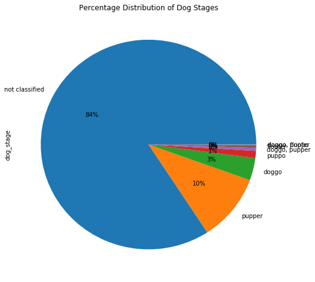

```python
enhanced_df.dog_stage.value_counts().plot(kind='pie', autopct= '%1.0f%%', figsize= (8,8), title= 'Percentage Distribution of Dog Stages');
```

## Insights

### 1. Analyzing the Relationship Between Retweet Counts and Favorite Counts

```
Text(0,0.5,'Count')
```

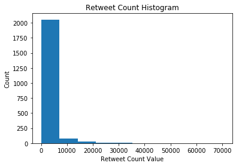

```python
enhanced_df['retweet_count'].plot(kind='hist', title='Retweet Count Histogram');
plt.xlabel('Retweet Count Value')
plt.ylabel('Count')
```

#### Apparently, our plot indicates that their are outliers, and it is skewed right

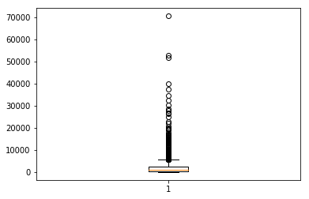

```python
# Using plotbox, lets identify the outliers
plt.boxplot(enhanced_df.retweet_count);
```

#### These outliers are seen to be slightly above 5000. Hence, we will plot for values below 5000

```
Text(0,0.5,'Count')
```

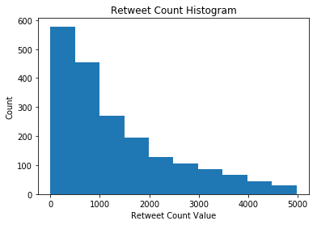

```python
enhanced_df=enhanced_df[enhanced_df.retweet_count < 5000].reset_index(drop=True)
enhanced_df['retweet_count'].plot(kind='hist', title='Retweet Count Histogram');
plt.xlabel('Retweet Count Value')
plt.ylabel('Count')
```

```python
# Now lets calculate the mean and standard deviation
print('Mean= {} and Standard Deviation= {}'.format(np.mean(enhanced_df.retweet_count), np.std(enhanced_df.retweet_count)))
```

```
Mean= 1306.105882352941 and Standard Deviation= 1152.671039082183
```

```
Text(0,0.5,'Count')
```

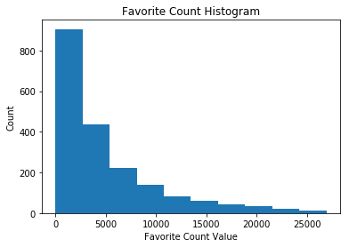

```python
# Similarly, lets plot the histogram of favorite_count
enhanced_df['favorite_count'].plot(kind='hist', title='Favorite Count Histogram');
plt.xlabel('Favorite Count Value')
plt.ylabel('Count')
```

#### Sighted outliers that needs to be omitted

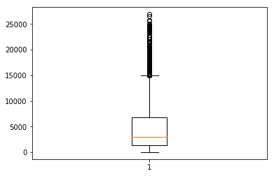

```python
plt.boxplot(enhanced_df.favorite_count);
```

#### These outliers are seen slightly above 15000

```
Text(0,0.5,'Count')
```

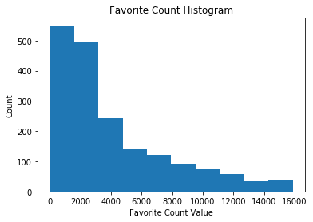

```python
enhanced_df=enhanced_df[enhanced_df.favorite_count < 16000].reset_index(drop=True)
enhanced_df['favorite_count'].plot(kind='hist', title='Favorite Count Histogram');
plt.xlabel('Favorite Count Value')
plt.ylabel('Count')
```

```python
# Again lets calculate the mean and standard deviation
print('Mean= {} and Standard Deviation= {}'.format(np.mean(enhanced_df.favorite_count), np.std(enhanced_df.favorite_count)))
```

```
Mean= 4035.7728997289973 and Standard Deviation= 3684.8799004410967
```

#### Next is to find the relationship between retweet_count and favorite_count

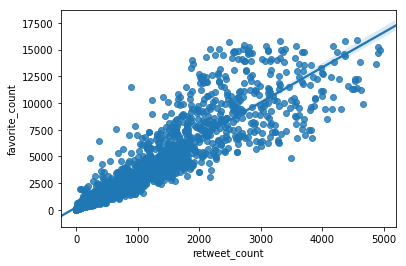

```python
import seaborn as sns
sns.regplot(enhanced_df.retweet_count, enhanced_df.favorite_count);
```

#### Relationship Between Retweet and Favorite Counts

```python
# Calculating the correlation coefficients
np.corrcoef(enhanced_df.retweet_count, enhanced_df.favorite_count)[0,1]
```

```
0.89606198034879403
```

#### This indicates that there is a strong and positive correlation between both variables

### 2. Analyzing the Relationship Between Retweet Counts and Rating Numerator

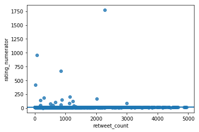

```python
sns.regplot(enhanced_df.retweet_count, enhanced_df.rating_numerator);
```

```python
#calculate correlation coefficients
np.corrcoef(enhanced_df.retweet_count, enhanced_df.rating_numerator)[0,1]
```

```
0.012639132988871097
```

#### This indicates a weak correlation

### 3. Analyzing the Histogram for the Rating Numerator

```python
# Now lets analyze the rating numerator
enhanced_df.describe()
```

|  | tweet_id | rating_numerator | retweet_count | favorite_count |
| --- | --- | --- | --- | --- |
| count | 1.845000e+03 | 1845.000000 | 1845.000000 | 1845.000000 |
| mean | 7.223579e+17 | 13.111669 | 1163.078591 | 4035.772900 |
| std | 5.632277e+16 | 50.919582 | 1007.424643 | 3685.878919 |
| min | 6.660209e+17 | 0.000000 | 0.000000 | 0.000000 |
| 25% | 6.748054e+17 | 10.000000 | 410.000000 | 1303.000000 |
| 50% | 6.994469e+17 | 11.000000 | 862.000000 | 2741.000000 |
| 75% | 7.590995e+17 | 12.000000 | 1688.000000 | 5840.000000 |
| max | 8.909719e+17 | 1776.000000 | 4944.000000 | 15885.000000 |

```
Text(0,0.5,'Count')
```

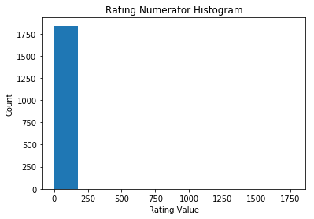

```python
enhanced_df['rating_numerator'].plot(kind='hist', title='Rating Numerator Histogram');
plt.xlabel('Rating Value')
plt.ylabel('Count')
```

```python
# Lets establish the confidence interval for the mean of the rating_numerator
table= enhanced_df.rating_numerator.sample(300)
```

```python
table_mean= np.random.choice(table, size=(10000, 200)).mean(axis=1)
table_mean
```

```
array([ 18.87 ,  28.85 ,  10.475, ...,  20.11 ,  19.3  ,  27.905])
```

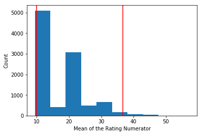

```python
fig, ax=plt.subplots()
left, right=np.percentile(table_mean, 2.5), np.percentile(table_mean, 97.5),
plt.hist(table_mean);
plt.title=('Confidence Interval for the Mean of Rating Numerator Histogram')
ax.set_xlabel('Mean of the Rating Numerator');
ax.set_ylabel('Count');
plt.axvline(left, color='r');
plt.axvline(right, color='r');
```

```python
print("Now the expected value for our mean population should be between {} and {}".format(left, right))
```

```
Now the expected value for our mean population should be between 9.99 and 36.65062499999999
```